# Homework #4

> **Student: Tom Bresee**

> Please let me know if something isn't working right, because I pretty much got everything to work, and have a fair amount of graphs as well, so if anything doesn't seem right (because it *should* look right), please email me at: tom.bresee@t-mobile.com or tom.bresee@gmail.com and I can resend the notebook or .html version if it helps...

> Note: I do use seaborn in places, so you have to have that loaded...

## Base Assumptions:

- **Win Percentage** - Very very simple: Win Percentage is (Number of Wins) / (Number of Wins + Number of Losses)
- **Year** - In our first wave of data analysis, we will be using exclusively information from the year **`2016`**. After this, i did in fact use all of the five years of previous data for all sports to analyze things as well. Also, we will specifically not examine other sports like soccer data.
- **Efficient Code** - I will try to use the most efficient python pandas commands to accomplish our goals. It is well understood that there are multiple ways of going things with pandas, but ideally the command should be the most streamlined and efficient (i.e. list comprehensions, etc). We will try to avoid brute force approaches and leverage the power of more advanced pandas commands.

  There will also be times where I attempt new things or techniques in order to learn and also demonstrate proficiency with the commands. One should also keep in mind that pandas itself is not perfect, and there may be configurations that are unusual or 'overloaded'.
- **Master Team Counts** - We will examine data associated with 51 total metro markets, and remember that in 2016 we had the following breakout of big four (NFL, NBA, MLB, and NHL) sports teams (for a total of 122 teams):

| Sport | Total Number of Active Teams (2016) |
| --- | --- |
| NFL | 32 |
| NBA | 30 |
| MLB | 30 |
| NHL | 30 |

- **Guideline** - Remember, correlation is *not* causation !
- **Caution** - One should be aware that drawing conclusions about correlation based on one physical year in the sport world is not a large sample size. In the wild world of sports, large fluctuations in team performance is normal (for instance, the NFL Superbowl winner one year may have an average season the next year). It is entirely possible/probable that there will be anomalies in any 'dimension' of sports...
- **Note** - There are situations where a sports teams is associated with a Metropolitan market that is not very close to it, for instance the New England Patriots are associated with Boston but are technically based out of Foxborough, MA; this city is actually relatively small but usually associated with the city of Boston, MA...
- **Reference Links**
  - Good Link for pulling the schedules and stats from NFL teams over the years
    - https://www.nfl.com/standings/division/2018/REG
  - Good .html form to use for future
    - https://www.lenovo.com/il/en/laptops/thinkpad/p-series/ThinkPad-P51/p/22TP2WPWP51
  - NHL raw data online
    - https://www.hockey-reference.com/leagues/NHL_2017.html
- **Visualization** - Important to help see the trends and relationships between teams and their performance !

## Some Observations:

- Green Bay throughout the years is techically a small area/population, but has a surprisingly high percentage of wins over the course of time.
- My personal opinion is that a lot of cities are 'sport towns', whether they are large in population or not...but we will let the data speak for itself.
- I also believe that some years there are a lot of good teams, and when everyone plays against each other, many win percentages arent high because all the teams caused occassional losses with other teams. In other words, not every year do you have a distribution of teams that range uniformly from great to good to ok to bad to terrible, sometimes you actually have years where in one division or season there are MANY good teams, and thus your win percentage will be lower just based on the data. This may skew our results slightly, its just something to keep in mind.
- Sometimes teams are carried by star players (anomalies), who can swing the win percentage in major ways...
- What we do see in some of the data is that the top three largest metropolitan areas sometimes have teams that have suprisingly low winning percentages !

## Approach:

- We have four main source of data:
  - nfl.csv: NFL Football related information
  - nba.csv: NBA Basketball related information
  - mlb.csv: MLB Baseball related information
  - nhl.csv: NHL Hockey related information
  - wikipedia_data.html: Master reference mapping sports teams to specific Metropolitan markets, Population, etc.
- Create our core dataframe `cities` which will contain information such as all Metro areas, Populations, and sport team data
- Create *individual* dataframes for each sport, which encompass specifically the team name and its calculated winning percentage
  - These dataframes will have a form that includes the sport name, i.e. `nfl` (football related), `nba` (basketball related), `mlb` (baseball related), `nhl`(hockey related)
- Clean data extremely thoroughly, removing elements/strings not needed
- Combine dataframes
- Create a set of 'mapping' dictionaries (mapping the team name to its Metropolitan area and Population)
- Correlation analysis between overall Metropolitan population and team winning percentages

*version 190910.0*

# Assignment 4

## Description

In this assignment you must read in a file of metropolitan regions and associated sports teams from assets/wikipedia_data.html and answer some questions about each metropolitan region. Each of these regions may have one or more teams from the "Big 4": NFL (football, in assets/nfl.csv), MLB (baseball, in assets/mlb.csv), NBA (basketball, in assets/nba.csv or NHL (hockey, in assets/nhl.csv). Please keep in mind that all questions are from the perspective of the metropolitan region, and that this file is the "source of authority" for the location of a given sports team. Thus teams which are commonly known by a different area (e.g. "Oakland Raiders") need to be mapped into the metropolitan region given (e.g. San Francisco Bay Area). This will require some human data understanding outside of the data you've been given (e.g. you will have to hand-code some names, and might need to google to find out where teams are)!

For each sport I would like you to answer the question: **what is the win/loss ratio's correlation with the population of the city it is in?** Remember that to calculate the correlation with [`pearsonr`](https://docs.scipy.org/doc/scipy/reference/generated/scipy.stats.pearsonr.html), so you are going to send in two ordered lists of values, the populations from the wikipedia_data.html file and the win/loss ratio for a given sport in the same order. Average the win/loss ratios for those cities which have multiple teams of a single sport. Each sport is worth an equal amount in this assignment (20%*4=80%) of the grade for this assignment.

In addition, I would like you to explore the hypothesis that **given that an area has two sports teams in different sports, those teams will perform the same within their respective sports**. How I would like to see this explored is with a series of paired t-tests (so use [`ttest_rel`](https://docs.scipy.org/doc/scipy/reference/generated/scipy.stats.ttest_rel.html)) between all pairs of sports. Are there any sports where we can reject the null hypothesis? Again, average values where a sport has multiple teams in one region. Remember, you will only be including, for each sport, cities which have teams engaged in that sport, drop others as appropriate. This question is worth 20% of the grade for this assignment.

## Notes

1. Partial marks may be awarded if the answer is incorrect, or removed even if the answer is correct! Within each function show your understanding of course concepts such as regex, `groupby()`, `apply()`, etc. as appropriate to the question. If you unnecessarily hand code data in your functions instead of using pandas cleaning mechanisms you may be docked grades.
2. Do not including data about the MLS or CFL in any of the work you are doing, we're only interested in the Big 4 in this assignment.
3. I highly suggest that you first tackle the correlation questions, as they are all similar and worth the majority of grades for this assignment. This is by design!
4. It's fair game to talk with peers about high level strategy as well as the relationship between metropolitan areas and sports teams. However, do not post code solving aspects of the assignment (including such as dictionaries mapping areas to teams, or regexes which will clean up names).
5. This assignment **is not autograded**. Go to the course shell and upload your .ipynb file there as assignment4.ipynb.
6. You can earn up to 100% on this assignment by creating correlations for a single year (2016) for which there is population data. You can earn up to 105% on this assignment by going further, and creating correlations for multiple years (e.g. across the years of data we have on the sports), but it's expected that there would be a short discussion of the limitations of your approach as far as interpretation goes. Finally, if you find new population data that covers a broader set of years and integrate it into a solution across these years and sports and provide that interpretation you can earn up to 110% on the assignment.

# 1a)

#### Beginning:

```python
#---  IMPORTING LIBRARIES  ---

import pandas as pd
import numpy as np
import html5lib
import requests
import scipy.stats as stats
import re
from bs4 import BeautifulSoup
from IPython.core.interactiveshell import InteractiveShell
from IPython.display import display, HTML
InteractiveShell.ast_node_interactivity = "all"
pd.set_option('display.max_rows', 500)
#  pd.set_option('mode.chained_assignment', None)
import matplotlib.pyplot as plt
%matplotlib inline
import seaborn as sns
sns.set()


# ---CREATING HELPER FUNCTIONS---
#    (When you are doing very large scale analysis, this can streamline confirmation checks)

# quick display
def sh(input):
    return display(input)


# sanity check
def check_my_count():
    print(" > COUNT CHECK")
    if (len(f_nfl)==32 and len(f_nba)==30 and len(f_mlb)==30 and len(f_nhl)==30):
        print('     Total sport team count . . . . . . . . . . . . . . . . . [OK]')
    else:
        print("Your math isn't adding up...")
```

```
Some Notes:


how to replace:
    df.replace(r'\s*(.*?)\s*', r'\1', regex=True)


how to .str.strip() across multiple columns at once:
    df[df_obj.columns] = df_obj.apply(lambda x: x.str.strip())
    df[df_obj.columns] = df_obj.apply(lambda x: x.str.strip())
    cities = cities.applymap(lambda x: x.strip() if isinstance(x, str) else x)
```

#### Building Core Metro/Cities Dataframe:

```python
#---  READ IN THE HTML DATA FILE OF METRO REGIONS AND SPORTS TEAMS  ---
cities=pd.read_html("assets/wikipedia_data.html")[1]

#---  ONLY USE CERTAIN COLUMNS LIKE THE METRO AREA, POPULATION, AND BIG FOUR SPORTS DATA  ---
cities=cities.iloc[:-1,[0,3,5,6,7,8]]#  removing last row which is just totals info

#  This *will* contain raw data that is uncleaned, so we will have to clean it

#  Looking at the first four rows of our raw dataframe...
sh(cities.head(4))

#  You can already see extra strings we don't need...
```

|  | Metropolitan area | Population (2016 est.)[8] | NFL | MLB | NBA | NHL |
| --- | --- | --- | --- | --- | --- | --- |
| 0 | New York City | 20153634 | GiantsJets[note 1] | YankeesMets[note 2] | KnicksNets | RangersIslandersDevils[note 3] |
| 1 | Los Angeles | 13310447 | RamsChargers[note 4] | DodgersAngels | LakersClippers | KingsDucks |
| 2 | San Francisco Bay Area | 6657982 | 49ersRaiders[note 6] | GiantsAthletics | Warriors | Sharks[note 7] |
| 3 | Chicago | 9512999 | Bears[note 8] | CubsWhite Sox | Bulls[note 9] | Blackhawks |

```python
#------------------------------[CLEANING]-------------------------------------

#---  STREAMLINED WAY OF CLEANING  ---
#  Note:  The fastest way to replace OVER an entire dataframe (versus a row), i think is below...

cities.replace(to_replace="\[.*\]", value='', inplace=True, regex=True)#  kill info in brackets
cities.replace(to_replace="—", value='', inplace=True, regex=True)#       kill dashes overhead
#  I could have merged these two commands but for clarity kept them sep

#---  CHANGE COLUMN NAMES  ---
#       -  I personally like to capitalize column names, makes things easier to see
cities.rename(columns={cities.columns[1]: "POP"}, inplace=True)#     clean approach
cities.rename(columns={cities.columns[0]: "METRO"}, inplace=True)#   clean approach

#---  CONVERT POPULATION COLUMN TO AN INTEGER DTYPE  ---
#     (It had defaulted to string/object dtype, which won't work for us)
#        -  Note:  When i imported the data, i could have prevented this step, but I'll show it for clarity
cities.POP   =   cities['POP'].astype(float)


#---  STRIP WHITESPACES JUST TO BE SAFE  ---
#   cities.METRO  =  cities.METRO.str.strip()
#   cities.NFL    =  cities.NFL.str.strip()
#   cities.MLB    =  cities.MLB.str.strip()
#   cities.NBA    =  cities.NBA.str.strip()
#   cities.NHL    =  cities.NHL.str.strip()
#     READ:  I am going to do all of the above in ONE line instead:
cities = cities.applymap(lambda x: x.strip() if isinstance(x, str) else x)

#  Looking at first rows of the cleaner dataframe...
sh(cities.head(16))

#  -  You do see some 'combined' names which represents multiple teams of the same sport in the same metro area
#  -  You also see that all of my columns are capitalized
#  -  IMPORTANT:  Do you see that some rows have missing information ?  (those are empty strings fyi)
#                 i.e. there are no NHL teams in Houston and Atlanta, and there is no NFL in Toronto
```

|  | METRO | POP | NFL | MLB | NBA | NHL |
| --- | --- | --- | --- | --- | --- | --- |
| 0 | New York City | 20,153,634.0000 | GiantsJets | YankeesMets | KnicksNets | RangersIslandersDevils |
| 1 | Los Angeles | 13,310,447.0000 | RamsChargers | DodgersAngels | LakersClippers | KingsDucks |
| 2 | San Francisco Bay Area | 6,657,982.0000 | 49ersRaiders | GiantsAthletics | Warriors | Sharks |
| 3 | Chicago | 9,512,999.0000 | Bears | CubsWhite Sox | Bulls | Blackhawks |
| 4 | Dallas–Fort Worth | 7,233,323.0000 | Cowboys | Rangers | Mavericks | Stars |
| 5 | Washington, D.C. | 6,131,977.0000 | Redskins | Nationals | Wizards | Capitals |
| 6 | Philadelphia | 6,070,500.0000 | Eagles | Phillies | 76ers | Flyers |
| 7 | Boston | 4,794,447.0000 | Patriots | Red Sox | Celtics | Bruins |
| 8 | Minneapolis–Saint Paul | 3,551,036.0000 | Vikings | Twins | Timberwolves | Wild |
| 9 | Denver | 2,853,077.0000 | Broncos | Rockies | Nuggets | Avalanche |
| 10 | Miami–Fort Lauderdale | 6,066,387.0000 | Dolphins | Marlins | Heat | Panthers |
| 11 | Phoenix | 4,661,537.0000 | Cardinals | Diamondbacks | Suns | Coyotes |
| 12 | Detroit | 4,297,617.0000 | Lions | Tigers | Pistons | Red Wings |
| 13 | Toronto | 5,928,040.0000 |  | Blue Jays | Raptors | Maple Leafs |
| 14 | Houston | 6,772,470.0000 | Texans | Astros | Rockets |  |
| 15 | Atlanta | 5,789,700.0000 | Falcons | Braves | Hawks |  |

**Remember:** Missing values that are empty strings aren't recognized by pandas as `null` ...

#### Let's look at the Metropolitan area population breakout for a sec..

```python
pd.options.display.float_format = '{:,.1f}'.format
#.apply(lambda x: '%.0f' % x)

#---  SHOW THE BREAKOUT OF ACTUAL POPULATIONS  ---
cities.POP.describe()
```

```
count           51.0
mean     3,562,337.3
std      3,439,762.4
min        236,481.0
25%      1,435,410.5
50%      2,429,609.0
75%      4,479,577.0
max     20,153,634.0
Name: POP, dtype: float64
```

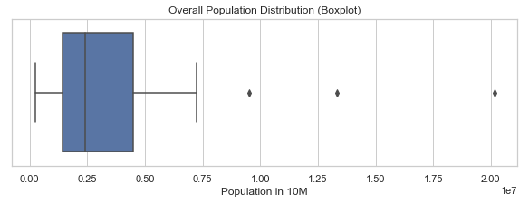

```python
#---  CREATING BOXPLOT IN SEABORN  ---
sns.set(style="whitegrid")
plt.figure(figsize=(10,3))
ax = sns.boxplot(x=cities["POP"])
ax.set_title('Overall Population Distribution (Boxplot)')
ax.set_xlabel('Population in 10M');
```

**Population Data:** * We have 51 total cities * The average city has a population of about 3.6 million people * The lowest city has a population of about 1/4 million people * New York (the largest city) has a population of **20 Million** ! * This is a PRETTY vast range of populations, in my opinion

#### Let's create the Big-4 sports dataframes:

**NOTE:** The original NHL .csv raw data had the years '2016' mistakenly labelled as '2017', so I needed to work around this...

```python
#---  CREATING SPORT DATAFRAMES FROM RAW DATA  ---

# READ:  Make sure your data files are under 'assets' folder !
mlb_df=pd.read_csv("assets/mlb.csv")
nhl_df=pd.read_csv("assets/nhl.csv")
nba_df=pd.read_csv("assets/nba.csv")
nfl_df=pd.read_csv("assets/nfl.csv")


print("\nI'm deliberately keeping the column headers the same for each big 4 sport...")
print("Looking at just the first four rows from each sport:")
print("[Percentages are in decimal form]")

pd.options.display.float_format = '{:,.4f}'.format



#-----------------------------[NFL]-------------------------------------

##############################################
#           Clean NFL raw data               #
##############################################

#---  MATCH BASED ON YEAR 2016 AND ON TEAMNAME NOT CONTAINING AFC OR NFC  ---
cl_nfl_df = nfl_df[  (nfl_df['year']==2016) & (~nfl_df['team'].str.contains('AFC|NFC'))  ].copy()

#---  REMOVE THE CHARACTER * AND + FROM THE RIGHT HAND SIDE OF CERTAIN CELLS  ---
cl_nfl_df.team = cl_nfl_df['team'].map(lambda x: x.rstrip('+|*'))
#clean_nfl_df['team'] = clean_nfl_df['team'].map(lambda x: str(x)[:-1])

#---  FINAL CLEAN AND CHECK  ---
cl_nfl_df.team = cl_nfl_df['team'].str.strip()  # just to make sure

##############################################
#           CREATE NFL WIN% DF               #
##############################################

f_nfl_df = cl_nfl_df#   new copy so i can reuse if i need to
#  ---  WINS AND LOSES ARE NEVER FRACTIONS !  ---
f_nfl_df.W = f_nfl_df.W.astype('int64')#   convert column W to type integer
f_nfl_df.L = f_nfl_df.L.astype('int64')#   convert column L to type integer

f_nfl_df['WIN_PCT'] = f_nfl_df['W'] / (f_nfl_df['L'] + f_nfl_df['W'])#   create NEW column:  WIN_PCT

f_nfl = f_nfl_df[ ['team','WIN_PCT'] ]#         return only specific cols
f_nfl.reset_index(inplace = True, drop=True)#   reset index to remove old

sh(f_nfl.head(4))#  Note:  You will have a total of 32 NFL teams


#-----------------------------[NBA]-------------------------------------

##############################################
#           Clean NBA raw data               #
##############################################

#---   MATCH BASED ON YEAR 2016   ---
cl_nba_df = nba_df[ nba_df['year']==2016 ].copy()

#---  USE YOUR BRAIN AND THINK OF TIGHT REGEX VERSUS ARCHAIC REMOVAL  ---
cl_nba_df['team'] = cl_nba_df['team'].str.extract(r'([A-Z].*[a-z])', expand=False)

#---  FINAL CLEAN AND CHECK  ---
cl_nba_df.team = cl_nba_df['team'].str.strip()  # just to make sure

##############################################
#           Create NBA win% df               #
##############################################

f_nba_df = cl_nba_df

f_nba_df.W = f_nba_df.W.astype('int64')
f_nba_df.L = f_nba_df.L.astype('int64')

f_nba_df['WIN_PCT'] = f_nba_df['W'] / (f_nba_df['L'] + f_nba_df['W'])

f_nba = f_nba_df[ ['team','WIN_PCT']]
f_nba.reset_index(inplace = True, drop=True)

sh(f_nba.head(4))#  Note:  You will have a total of 30 NBA teams


#-----------------------------[MLB]-------------------------------------

##############################################
#           Clean MLB raw data               #
##############################################

#---  MATCH BASED ON YEAR 2016  ---
cl_mlb_df = mlb_df[mlb_df['year']==2016].copy()

#---  FINAL CLEAN AND CHECK  ---
cl_mlb_df.team = cl_mlb_df['team'].str.strip()

##############################################
#           Create MLB win% df               #
##############################################

f_mlb_df = cl_mlb_df

f_mlb_df.W = f_mlb_df.W.astype('int64')
f_mlb_df.L = f_mlb_df.L.astype('int64')

f_mlb_df['WIN_PCT'] = f_mlb_df['W'] / (f_mlb_df['L'] + f_mlb_df['W'])

f_mlb = f_mlb_df[ ['team','WIN_PCT']]
f_mlb.reset_index(inplace = True, drop=True)

sh(f_mlb.head(4))#  Note:  There will be a total of 30 MLB teams


#-----------------------------[NHL]-------------------------------------

##############################################
#           Clean NHL raw data               #
##############################################

#---  MATCH BASED ON YEAR 2017  ---
#---  (then reduce back to true 2016)  ---
cl_nhl_df = nhl_df[nhl_df['year']==2017].copy()

#---  IF TEAM CONTAINS 'Division' THEN REMOVE IT  ---
cl_nhl_df =  cl_nhl_df[~cl_nhl_df.team.str.contains("Division")]

#---  REMOVE THE CHARACTER * FROM THE RIGHT HAND SIDE  ---
cl_nhl_df.team = cl_nhl_df['team'].map(lambda x: x.rstrip('*'))

#---  FINAL CLEAN AND CHECK  ---
cl_nhl_df.team = cl_nhl_df['team'].str.strip()

##############################################
#           Create NHL win% df               #
##############################################

f_nhl_df = cl_nhl_df

f_nhl_df.W = f_nhl_df.W.astype('int64')
f_nhl_df.L = f_nhl_df.L.astype('int64')

f_nhl_df['WIN_PCT'] = f_nhl_df['W'] / (f_nhl_df['L'] + f_nhl_df['W'])

#---  THIS IS TRICKY:  I HAD MISLABELLED DATA, I HAD TO MANUALLY FIX THE YEARS DATA !  ---
f_nhl = f_nhl_df[ ['team','WIN_PCT']][-30:]
#f_nhl = f_nhl_df[-30:]

f_nhl.reset_index(inplace = True, drop=True)

sh(f_nhl.head(4))
#__Note:  30 total nhl teams (but after 2016 it was actually 31)

check_my_count()
```

```
I'm deliberately keeping the column headers the same for each big 4 sport...
Looking at just the first four rows from each sport:
[Percentages are in decimal form]
```

|  | team | WIN_PCT |
| --- | --- | --- |
| 0 | New England Patriots | 0.8750 |
| 1 | Miami Dolphins | 0.6250 |
| 2 | Buffalo Bills | 0.4375 |
| 3 | New York Jets | 0.3125 |

|  | team | WIN_PCT |
| --- | --- | --- |
| 0 | Cleveland Cavaliers | 0.6951 |
| 1 | Toronto Raptors | 0.6829 |
| 2 | Miami Heat | 0.5854 |
| 3 | Atlanta Hawks | 0.5854 |

|  | team | WIN_PCT |
| --- | --- | --- |
| 0 | Boston Red Sox | 0.5741 |
| 1 | Baltimore Orioles | 0.5494 |
| 2 | Toronto Blue Jays | 0.5494 |
| 3 | New York Yankees | 0.5185 |

|  | team | WIN_PCT |
| --- | --- | --- |
| 0 | Florida Panthers | 0.6438 |
| 1 | Tampa Bay Lightning | 0.5974 |
| 2 | Detroit Red Wings | 0.5775 |
| 3 | Boston Bruins | 0.5753 |

```
 > COUNT CHECK
     Total sport team count . . . . . . . . . . . . . . . . . [OK]
```

#### I'm going to take a detour here for a sec and do some cool stuff

```python
#---  LETS CREATE A SUPER DF OF ALL SPORTS TEAMS AND THEIR RAW WIN_PCT  ---
#     (Concatenate the raw df you created above to stack them vertically)
all_teams_win_pct = pd.concat([f_nfl,f_nba, f_mlb, f_nhl])
all_teams_win_pct.reset_index(inplace=True, drop=True)


sh(all_teams_win_pct[['team', 'WIN_PCT']].head())

# Note:  I have created one master dataframe of **all of the sports teams ** and their winning percentage
#        Now I can examine raw data without caring about the actual sport involved, only the overall WIN_PCT ...
#        Showing first five rows as an example...
```

|  | team | WIN_PCT |
| --- | --- | --- |
| 0 | New England Patriots | 0.8750 |
| 1 | Miami Dolphins | 0.6250 |
| 2 | Buffalo Bills | 0.4375 |
| 3 | New York Jets | 0.3125 |
| 4 | Pittsburgh Steelers | 0.6875 |

```python
#---  LETS ORGANIZE THIS SUPER DF IN DESCENDING ORDER OF WIN_PCT  ---
#     (THIS WILL SHOW THE *WINNINGEST* TEAMS, irrespective of sport)

temp = all_teams_win_pct
temp = temp.sort_values('WIN_PCT', ascending=False)
print("\nThe following shows the top ten winningest sports franchises (in winning percentage) \nof the 122 total sports teams in the 2016 season, irrespective of sport...")
#print(all_teams_win_pct.head(10).to_string(index=False))

temp.WIN_PCT = temp['WIN_PCT']*100  # percentage values, not decimal !
temp.WIN_PCT = temp['WIN_PCT'].round(3)
temp.reset_index(inplace=True, drop=True)
display(HTML(temp.head(10).to_html(index=False)))  # i like pretty (removing the index!)
```

```
The following shows the top ten winningest sports franchises (in winning percentage)
of the 122 total sports teams in the 2016 season, irrespective of sport...
```

| team | WIN_PCT |
| --- | --- |
| Golden State Warriors | 89.0240 |
| New England Patriots | 87.5000 |
| San Antonio Spurs | 81.7070 |
| Dallas Cowboys | 81.2500 |
| Washington Capitals | 75.6760 |
| Kansas City Chiefs | 75.0000 |
| Oakland Raiders | 75.0000 |
| Cleveland Cavaliers | 69.5120 |
| Pittsburgh Steelers | 68.7500 |
| Atlanta Falcons | 68.7500 |

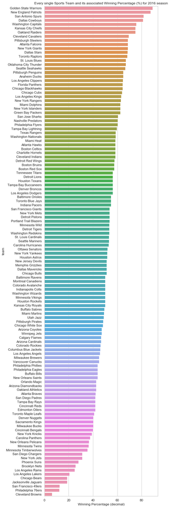

```python
#### Let's take a look at this graphed by WIN_PCT (across all teams)

sns.set(style="whitegrid")
plt.figure(figsize=(7,31))
ax = sns.barplot(x=temp['WIN_PCT'], y=temp['team'])
ax.set_title('Every single Sports Team and its associated Winning Percentage (%) for 2016 season')
ax.set_xlabel('Winning Percentage (decimal)');
```

#### Back to business: I will need to create a dictionary of team-name < = > to Metro area (across all sports):

#### Creating first df (NFL) for mapping

```python
#---     CREATING FOUR DFS, MAPPING A TEAM WITH A METRO AREA  ---
#      (THEN MERGE THEM, CONVERT TO A DICTIONARY, TO USE AS A MAPPER)
#   (YOU COULD ALSO KEEP THEM SEPARATE TO USE INDIVIDUALLY PER SPORT IF YOU WANTED)

# df.set_index('A').to_dict()['B']
#cities.Series(df.Letter.values,index=df.Position).to_dict()
#dict(zip(cities.NFL, cities.Metro))

t1 = cities[['NFL','METRO']].copy()
t1 = t1[t1.NFL != ''].reset_index(drop=True)#  Removing rows with missing strings

#  Note:  I have to break out metro areas that have multiple teams of the same sport !
t1 = t1.append({'NFL' : 'Giants' , 'METRO' : 'New York City'} , ignore_index=True)
t1 = t1.append({'NFL' : 'Jets' , 'METRO' : 'New York City'} , ignore_index=True)
t1 = t1.append({'NFL' : 'Rams' , 'METRO' : 'Los Angeles'} , ignore_index=True)
t1 = t1.append({'NFL' : 'Chargers' , 'METRO' : 'Los Angeles'} , ignore_index=True)
t1 = t1.append({'NFL' : '49ers' , 'METRO' : 'San Francisco Bay Area'} , ignore_index=True)
t1 = t1.append({'NFL' : 'Raiders' , 'METRO' : 'San Francisco Bay Area'} , ignore_index=True)
t1.METRO = t1.METRO.str.strip()#  clean whitespaces to be safe


t1 = t1[3:].reset_index(drop=True)  # THIS IS NOW A TRUE MAPPER FOR NFL TEAMS TO METRO AREAS
#  By the way, i like to reset index, keeps the numbers in a row and easier on the viewer...

sh(t1.head(10))  # maps from the team name over to the METRO location...
#  Showing the first ten rows so you get the point.  We do this for each sport...
```

|  | NFL | METRO |
| --- | --- | --- |
| 0 | Bears | Chicago |
| 1 | Cowboys | Dallas–Fort Worth |
| 2 | Redskins | Washington, D.C. |
| 3 | Eagles | Philadelphia |
| 4 | Patriots | Boston |
| 5 | Vikings | Minneapolis–Saint Paul |
| 6 | Broncos | Denver |
| 7 | Dolphins | Miami–Fort Lauderdale |
| 8 | Cardinals | Phoenix |
| 9 | Lions | Detroit |

#### Creating second df (NBA) for mapping

```python
#  cities[['NBA','METRO']]
```

```python
t2 = cities[['NBA','METRO']].copy()
t2 = t2[t2.NBA != ''].reset_index(drop=True)


#  Breaking out multi-sport-teams
t2 = t2.append({'NBA' : 'Knicks' , 'METRO' : 'New York City'} , ignore_index=True)
t2 = t2.append({'NBA' : 'Nets' , 'METRO' : 'New York City'} , ignore_index=True)
t2 = t2.append({'NBA' : 'Lakers' , 'METRO' : 'Los Angeles'} , ignore_index=True)
t2 = t2.append({'NBA' : 'Clippers' , 'METRO' : 'Los Angeles'} , ignore_index=True)
t2.METRO = t2.METRO.str.strip()


t2 = t2[2:].reset_index(drop=True) #  THIS IS NOW A TRUE MAPPER FOR NBA TEAMS TO METRO AREAS
```

#### Creating third df (MLB) for mapping

```python
t3 = cities[['MLB','METRO']].copy()

t3 = t3[t3.MLB != ''].reset_index(drop=True)

t3 = t3.append({'MLB' : 'Yankees' , 'METRO' : 'New York City'} , ignore_index=True)
t3 = t3.append({'MLB' : 'Mets' , 'METRO' : 'New York City'} , ignore_index=True)
t3 = t3.append({'MLB' : 'Dodgers' , 'METRO' : 'Los Angeles'} , ignore_index=True)
t3 = t3.append({'MLB' : 'Angels' , 'METRO' : 'Los Angeles'} , ignore_index=True)
t3 = t3.append({'MLB' : 'Giants' , 'METRO' : 'San Francisco Bay Area'} , ignore_index=True)
t3 = t3.append({'MLB' : 'Athletics' , 'METRO' : 'San Francisco Bay Area'} , ignore_index=True)
t3 = t3.append({'MLB' : 'Cubs' , 'METRO' : 'Chicago'} , ignore_index=True)
t3 = t3.append({'MLB' : 'White Sox' , 'METRO' : 'Chicago'} , ignore_index=True)
t3.METRO = t3.METRO.str.strip()

#  --- Removing the first four rows ---
t3 = t3[4:].reset_index(drop=True)  #  THIS IS NOW A TRUE MAPPER FOR MLB TEAMS TO METRO AREAS
```

#### Creating fourth df (NHL) for mapping

**WARNING:** You have to remove the Vegas Golden Knights, they were NOT a team in 2016 !

```python
t4 = cities[['NHL','METRO']].copy()

t4 = t4[t4.NHL != ''].reset_index(drop=True)  # remove rows with missing teams
t4 = t4[t4.NHL != 'Golden Knights']#  important to remove !

t4 = t4.append({'NHL' : 'Rangers' , 'METRO' : 'New York City'} , ignore_index=True)
t4 = t4.append({'NHL' : 'Islanders' , 'METRO' : 'New York City'} , ignore_index=True)
t4 = t4.append({'NHL' : 'Devils' , 'METRO' : 'New York City'} , ignore_index=True)
t4 = t4.append({'NHL' : 'Kings' , 'METRO' : 'Los Angeles'} , ignore_index=True)
t4 = t4.append({'NHL' : 'Ducks' , 'METRO' : 'Los Angeles'} , ignore_index=True)
t4.METRO = t4.METRO.str.strip()

t4 = t4[2:].reset_index(drop=True) #  THIS IS NOW A TRUE MAPPER FOR NHL TEAMS TO METRO AREAS
```

#### Now let's create a series of dictionaries to allow easy mapping

```python
#---  EACH OF THESE DICTIONARIES MAPS A SPORT TEAM TO ITS ASSOCIATED METRO AREA  ---
#     (I have specifically also made the `index` to be the sports team for clarity)
d1 = t1.set_index('NFL').to_dict()['METRO']
d2 = t2.set_index('NBA').to_dict()['METRO']
d3 = t3.set_index('MLB').to_dict()['METRO']
d4 = t4.set_index('NHL').to_dict()['METRO']

if len(d1.keys()) + len(d2.keys()) + len(d3.keys()) + len(d4.keys()) == 122:
    print('CHECK COMPLETE: YOU ARE IN FACT SHOWING 122 TOTAL ENTRIES IN YOUR DICT COUNTS')
```

```
CHECK COMPLETE: YOU ARE IN FACT SHOWING 122 TOTAL ENTRIES IN YOUR DICT COUNTS
```

#### Do we have any duplicates in any team names ???

```python
#---  IM GOING TO DETERMINE IF I HAVE DUPLICATE TEAM NAMES !  ---
all_dict_key_entries = list(d1.keys()) + list(d2.keys()) + list(d3.keys()) + list(d4.keys())

print("\nNOTE:  The following teams are in fact duplicates across the four sports categories:\n")
for team in set([x for x in all_dict_key_entries if all_dict_key_entries.count(x) > 1]):  print("  - ",team)

print("\n  *For instance:  Texas Rangers (baseball) and NY Rangers (hockey)\n")
```

```
NOTE:  The following teams are in fact duplicates across the four sports categories:

  -  Jets
  -  Giants
  -  Kings
  -  Cardinals
  -  Rangers
  -  Panthers

  *For instance:  Texas Rangers (baseball) and NY Rangers (hockey)
```

```python
#---  I CREATED A SUPER MAPPER HERE ACROSS *ALL* FOUR CATEGORIES OF SPORTS  ---
#     (But i don't actually need the super mapper, so i will comment it out)
# superD = dict(d1, **d2)
# superD = dict(superD, **d3)
# superD = dict(superD, **d4)
# TRUE_MAPPER = superD
# len(TRUE_MAPPER.keys())
```

```python
#----------------[ENTER YOUR TEAMNAME, RETURNS YOUR METRO AREA THEY LIVE IN]---------------------

# def MetroFinder(df, mystr):
#     for sport in df:
#         for team_cell in df[sport]:
#             if mystr in team_cell:
#                 return sport

# print(MetroFinder(super_mapper, 'Grizzlies'))
```

```python
#  if 'Heat' in list(cities.NBA):  print('match')
```

```python
# for row in Y.Nickname:
#     if row isin cities.NBA:
#         print("*** match ***")

#         df2.col.isin(df1.col)

# for coll in Y:
#     if Y.coll.isin(cities.NBA):
#         print("***")
```

## So let's close the deal here:

```python
#  Note:
#   -  I fundamentally make an assumption here
#   -  I will completely redo this section again with a different assumption in the next major section
```

### - NFL:

```python
#---  d1 is a previously created dictionary that maps nfl teams to the metro city  ---
#             (We will do this same approach for each sport)

print("Nicely created dictionary we will use to map the NFL teamname to the Metro Area: ")
sh(d1)

# Note:  I find that mapping via a dictionary is powerful and probably the most convenient way.
#        I could have done it another way, but I think this is the best approach...
```

```
Nicely created dictionary we will use to map the NFL teamname to the Metro Area:
```

```
{'49ers': 'San Francisco Bay Area',
 'Bears': 'Chicago',
 'Bengals': 'Cincinnati',
 'Bills': 'Buffalo',
 'Broncos': 'Denver',
 'Browns': 'Cleveland',
 'Buccaneers': 'Tampa Bay Area',
 'Cardinals': 'Phoenix',
 'Chargers': 'Los Angeles',
 'Chiefs': 'Kansas City',
 'Colts': 'Indianapolis',
 'Cowboys': 'Dallas–Fort Worth',
 'Dolphins': 'Miami–Fort Lauderdale',
 'Eagles': 'Philadelphia',
 'Falcons': 'Atlanta',
 'Giants': 'New York City',
 'Jaguars': 'Jacksonville',
 'Jets': 'New York City',
 'Lions': 'Detroit',
 'Packers': 'Green Bay',
 'Panthers': 'Charlotte',
 'Patriots': 'Boston',
 'Raiders': 'San Francisco Bay Area',
 'Rams': 'Los Angeles',
 'Ravens': 'Baltimore',
 'Redskins': 'Washington, D.C.',
 'Saints': 'New Orleans',
 'Seahawks': 'Seattle',
 'Steelers': 'Pittsburgh',
 'Texans': 'Houston',
 'Titans': 'Nashville',
 'Vikings': 'Minneapolis–Saint Paul'}
```

```python
#---  f_nfl is the consolidated team and WIN_PCT for that nfl team

#---  Add nickname of the last word of the team  ---
nfl2 = f_nfl.copy()
nfl2['Nickname'] = f_nfl['team'].apply(lambda x: x.split()[-1]).copy()

#---  MAP THE TEAM NICKNAME TO THE METRO AREA IT IS ASSOCIATED WITH  ---
#     THIS IS THE MAGIC
nfl2['MSO'] = nfl2['Nickname'].map(d1)



#---  Creating map link from metro area to master population  ---
metro_to_pop = cities.loc[:, ['METRO', 'POP']].copy()

#---  Flip it to a dictionary to make it clean  ---
metro_to_pop_DB = metro_to_pop.set_index('METRO').to_dict()['POP']


#---  The Population value is now to be mapped appropriated (associated with correct METRO)
nfl2['Population'] = nfl2.MSO.map(metro_to_pop_DB)

#---  show first five rows of final nfl dataframe  ---
nfl2.sort_values('Population', ascending=False, inplace=True)#  Show based on descending population

#  For clarity, I'm going to show what our final NFL dataset looks like, and of course,
#  we will create four separate datasets, one for each sport...
nfl2.reset_index(inplace=True, drop=True)#  resetting index

display(HTML(nfl2.to_html(index=False)))   # i like pretty
```

| team | WIN_PCT | Nickname | MSO | Population |
| --- | --- | --- | --- | --- |
| New York Jets | 0.3125 | Jets | New York City | 20,153,634.0000 |
| New York Giants | 0.6875 | Giants | New York City | 20,153,634.0000 |
| Los Angeles Rams | 0.2500 | Rams | Los Angeles | 13,310,447.0000 |
| San Diego Chargers | 0.3125 | Chargers | Los Angeles | 13,310,447.0000 |
| Chicago Bears | 0.1875 | Bears | Chicago | 9,512,999.0000 |
| Dallas Cowboys | 0.8125 | Cowboys | Dallas–Fort Worth | 7,233,323.0000 |
| Houston Texans | 0.5625 | Texans | Houston | 6,772,470.0000 |
| Oakland Raiders | 0.7500 | Raiders | San Francisco Bay Area | 6,657,982.0000 |
| San Francisco 49ers | 0.1250 | 49ers | San Francisco Bay Area | 6,657,982.0000 |
| Washington Redskins | 0.5333 | Redskins | Washington, D.C. | 6,131,977.0000 |
| Philadelphia Eagles | 0.4375 | Eagles | Philadelphia | 6,070,500.0000 |
| Miami Dolphins | 0.6250 | Dolphins | Miami–Fort Lauderdale | 6,066,387.0000 |
| Atlanta Falcons | 0.6875 | Falcons | Atlanta | 5,789,700.0000 |
| New England Patriots | 0.8750 | Patriots | Boston | 4,794,447.0000 |
| Arizona Cardinals | 0.4667 | Cardinals | Phoenix | 4,661,537.0000 |
| Detroit Lions | 0.5625 | Lions | Detroit | 4,297,617.0000 |
| Seattle Seahawks | 0.6667 | Seahawks | Seattle | 3,798,902.0000 |
| Minnesota Vikings | 0.5000 | Vikings | Minneapolis–Saint Paul | 3,551,036.0000 |
| Tampa Bay Buccaneers | 0.5625 | Buccaneers | Tampa Bay Area | 3,032,171.0000 |
| Denver Broncos | 0.5625 | Broncos | Denver | 2,853,077.0000 |
| Baltimore Ravens | 0.5000 | Ravens | Baltimore | 2,798,886.0000 |
| Carolina Panthers | 0.3750 | Panthers | Charlotte | 2,474,314.0000 |
| Pittsburgh Steelers | 0.6875 | Steelers | Pittsburgh | 2,342,299.0000 |
| Cincinnati Bengals | 0.4000 | Bengals | Cincinnati | 2,165,139.0000 |
| Kansas City Chiefs | 0.7500 | Chiefs | Kansas City | 2,104,509.0000 |
| Cleveland Browns | 0.0625 | Browns | Cleveland | 2,055,612.0000 |
| Indianapolis Colts | 0.5000 | Colts | Indianapolis | 2,004,230.0000 |
| Tennessee Titans | 0.5625 | Titans | Nashville | 1,865,298.0000 |
| Jacksonville Jaguars | 0.1875 | Jaguars | Jacksonville | 1,478,212.0000 |
| New Orleans Saints | 0.4375 | Saints | New Orleans | 1,268,883.0000 |
| Buffalo Bills | 0.4375 | Bills | Buffalo | 1,132,804.0000 |
| Green Bay Packers | 0.6250 | Packers | Green Bay | 318,236.0000 |

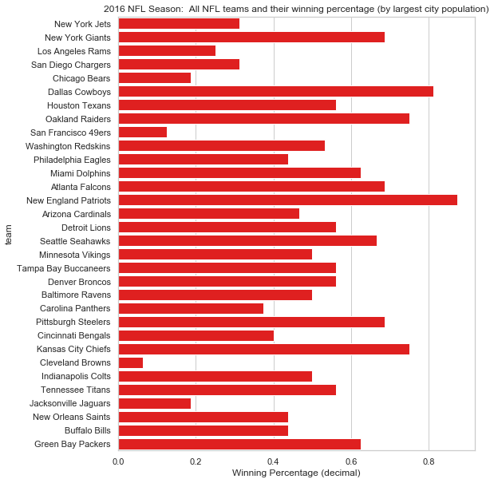

```python
#### Let's take a look at this graphed by WIN_PCT

sns.set(style="whitegrid")
plt.figure(figsize=(8,10))
ax = sns.barplot(x=nfl2['WIN_PCT'], y=nfl2['team'], color='red')
ax.set_title('2016 NFL Season:  All NFL teams and their winning percentage (by largest city population)')
ax.set_xlabel('Winning Percentage (decimal)');
```

- STOP and look at this data above
- This is all the teams organized in *order* of Metro Population (highest pop to lowest pop) ! ! !
- You can thus get an idea IF visually you see that larger cities have higher percentages ! ! !

```python
def nfl_correlation():
    population_by_region = nfl2.Population
    win_loss_by_region = nfl2.WIN_PCT
    return stats.pearsonr(population_by_region, win_loss_by_region)

nfl_correlation()
```

```
(-0.10693047307414547, 0.5602311525849389)
```

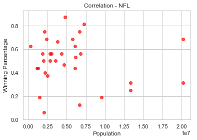

```python
#---  EXAMINING THE NFL DATA SCATTER PLOT  ---

x = nfl2.Population
y = nfl2.WIN_PCT
plt.scatter(x, y, c='red', alpha=.7)
plt.title("Correlation - NFL")
plt.xlabel("Population")
plt.ylabel("Winning Percentage")
#, s=area, c=colors, alpha=0.5)
#  plt.scatter(x, y, s=area, c=colors, alpha=0.5)
plt.ylim(0)
plt.show();
```

**Thoughts:** * x-axis = Metro Population, y-axis = Winning Percentage * As the population increases, there is not necessarily an increase in winning percentage, and in fact, somewhat quite the opposite. I would say there isn't strong evidence hear of correlation, but technically it is slightly negative. * Need to be aware that using this function, it is generally assumped that each dataset is normally distributed, and in our case it isnt that normally distributed in general... * https://en.wikipedia.org/wiki/Pearson_correlation_coefficient

```python
#  Some visual references (below) to understand the correlation values:
```

[figure not shown]

**Translation:**

- 0 indicates no linear relationship
- +1 indicates a perfect positive linear relationship: as one variable increases in its values, the other variable also increases in its values via an exact linear rule.
- -1 indicates a perfect negative linear relationship: as one variable increases in its values, the other variable decreases in its values via an exact linear rule.
- Values between 0 and 0.3 (0 and -0.3) indicate a weak positive (negative) linear relationship via a shaky linear rule.
- Values between 0.3 and 0.7 (-0.3 and -0.7) indicate a moderate positive (negative) linear relationship via a fuzzy-firm linear rule.
- Values between 0.7 and 1.0 (-0.7 and -1.0) indicate a strong positive (negative) linear relationship via a firm linear rule.

### - NBA:

```python
#  d2 is the previously created dictionary to map NBA teams to Metro Areas
```

```python
#---  f_nba is the consolidated team and WIN_PCT for that nba team
#---  Add nickname of the last word of the team  ---
nba2 = f_nba.copy()
nba2['Nickname'] = f_nba['team'].apply(lambda x: x.split()[-1]).copy()
nba2.replace({'Blazers': 'Trail Blazers'}, inplace=True)

#---  MAP THE TEAM NICKNAME TO THE METRO AREA IT IS ASSOCIATED WITH  ---
nba2['MSO'] = nba2['Nickname'].map(d2)#  always make sure you are using the right dictionary !



#---  Creating map link from metro area to master population  ---
#  already exists from earlier:  metro_to_pop = cities.loc[:, ['METRO', 'POP']].copy()
#  already exists from earlier:  metro_to_pop_DB = metro_to_pop.set_index('METRO').to_dict()['POP']

#---  The Population value is now to be mapped appropriated (associated with correct METRO)
nba2['Population'] = nba2.MSO.map(metro_to_pop_DB)



#---  show first five rows of final nba dataframe  ---
nba2.sort_values('Population', ascending=False, inplace=True)#  Show based on descending population
nba2.reset_index(inplace=True, drop=True)#  resetting index

display(HTML(nba2.to_html(index=False)))   # i like pretty (no index)
```

| team | WIN_PCT | Nickname | MSO | Population |
| --- | --- | --- | --- | --- |
| Brooklyn Nets | 0.2561 | Nets | New York City | 20,153,634.0000 |
| New York Knicks | 0.3902 | Knicks | New York City | 20,153,634.0000 |
| Los Angeles Lakers | 0.2073 | Lakers | Los Angeles | 13,310,447.0000 |
| Los Angeles Clippers | 0.6463 | Clippers | Los Angeles | 13,310,447.0000 |
| Chicago Bulls | 0.5122 | Bulls | Chicago | 9,512,999.0000 |
| Dallas Mavericks | 0.5122 | Mavericks | Dallas–Fort Worth | 7,233,323.0000 |
| Houston Rockets | 0.5000 | Rockets | Houston | 6,772,470.0000 |
| Golden State Warriors | 0.8902 | Warriors | San Francisco Bay Area | 6,657,982.0000 |
| Washington Wizards | 0.5000 | Wizards | Washington, D.C. | 6,131,977.0000 |
| Philadelphia 76ers | 0.1220 | 76ers | Philadelphia | 6,070,500.0000 |
| Miami Heat | 0.5854 | Heat | Miami–Fort Lauderdale | 6,066,387.0000 |
| Toronto Raptors | 0.6829 | Raptors | Toronto | 5,928,040.0000 |
| Atlanta Hawks | 0.5854 | Hawks | Atlanta | 5,789,700.0000 |
| Boston Celtics | 0.5854 | Celtics | Boston | 4,794,447.0000 |
| Phoenix Suns | 0.2805 | Suns | Phoenix | 4,661,537.0000 |
| Detroit Pistons | 0.5366 | Pistons | Detroit | 4,297,617.0000 |
| Minnesota Timberwolves | 0.3537 | Timberwolves | Minneapolis–Saint Paul | 3,551,036.0000 |
| Denver Nuggets | 0.4024 | Nuggets | Denver | 2,853,077.0000 |
| Charlotte Hornets | 0.5854 | Hornets | Charlotte | 2,474,314.0000 |
| Orlando Magic | 0.4268 | Magic | Orlando | 2,441,257.0000 |
| San Antonio Spurs | 0.8171 | Spurs | San Antonio | 2,429,609.0000 |
| Portland Trail Blazers | 0.5366 | Trail Blazers | Portland | 2,424,955.0000 |
| Sacramento Kings | 0.4024 | Kings | Sacramento | 2,296,418.0000 |
| Cleveland Cavaliers | 0.6951 | Cavaliers | Cleveland | 2,055,612.0000 |
| Indiana Pacers | 0.5488 | Pacers | Indianapolis | 2,004,230.0000 |
| Milwaukee Bucks | 0.4024 | Bucks | Milwaukee | 1,572,482.0000 |
| Oklahoma City Thunder | 0.6707 | Thunder | Oklahoma City | 1,373,211.0000 |
| Memphis Grizzlies | 0.5122 | Grizzlies | Memphis | 1,342,842.0000 |
| New Orleans Pelicans | 0.3659 | Pelicans | New Orleans | 1,268,883.0000 |
| Utah Jazz | 0.4878 | Jazz | Salt Lake City | 1,186,187.0000 |

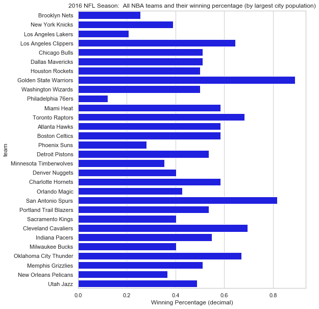

```python
#### Let's take a look at this graphed by WIN_PCT

sns.set(style="whitegrid")
plt.figure(figsize=(8,10))
ax = sns.barplot(x=nba2['WIN_PCT'], y=nba2['team'], color='blue')
ax.set_title('2016 NFL Season:  All NBA teams and their winning percentage (by largest city population)')
ax.set_xlabel('Winning Percentage (decimal)');

# Look closely:  This is all the teams organized in order of Metro Population ! ! ! ! ! !
#                You can thus get an idea IF visually you see that larger cities have higher percentages ! ! !
```

- STOP and look at this data above
- This is all the teams organized in *order* of Metro Population (highest pop to lowest pop) ! ! !
- You can thus get an idea IF visually you see that larger cities have higher percentages ! ! !

```python
def nba_correlation():
    population_by_region = nba2.Population
    win_loss_by_region = nba2.WIN_PCT
    return stats.pearsonr(population_by_region, win_loss_by_region)

nba_correlation()
```

```
(-0.267010334937334, 0.1537583483307225)
```

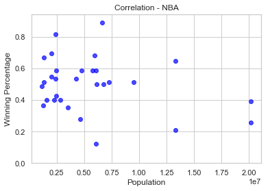

```python
#---  EXAMINING THE NBA DATA SCATTER PLOT  ---

x = nba2.Population
y = nba2.WIN_PCT
plt.scatter(x, y, c='blue', alpha=.7)
plt.title("Correlation - NBA")
plt.xlabel("Population")
plt.ylabel("Winning Percentage")
#, s=area, c=colors, alpha=0.5)
#  plt.scatter(x, y, s=area, c=colors, alpha=0.5)
plt.ylim(0)
plt.show();
```

**Thoughts:** * As the population increases, there appears to be an inverse relationship of losing percentage * -.267 tells the story there is somewhat of an inverse relationship. This is not significant but it is definitely present. In other words, there appears to be a weak negative linear relationship between the variables.

### - MLB:

```python
#  d3 is the previously created dictionary to map NBA teams to Metro Areas
```

```python
#---  f_mlb is the consolidated team and WIN_PCT for that mlb team
mlb2 = f_mlb.copy()
mlb2['Nickname'] = f_mlb['team'].apply(lambda x: x.split()[-1]).copy()
mlb2.replace({'Jays': 'Blue Jays'}, inplace=True); mlb2.iloc[8,2] = 'White Sox'
mlb2.iloc[0,2] = 'Red Sox'

#---  MAP THE TEAM NICKNAME TO THE METRO AREA IT IS ASSOCIATED WITH  ---
mlb2['MSO'] = mlb2['Nickname'].map(d3)
#---  The Population value is now to be mapped appropriated (associated with correct METRO)
mlb2['Population'] = mlb2.MSO.map(metro_to_pop_DB)
#  sh(mlb2.sort_values('Population', ascending=False))
#  sh(mlb2)
mlb2.sort_values('Population', ascending=False, inplace=True)
mlb2.reset_index(inplace=True, drop=True)#

display(HTML(mlb2.to_html(index=False)))
```

| team | WIN_PCT | Nickname | MSO | Population |
| --- | --- | --- | --- | --- |
| New York Mets | 0.5370 | Mets | New York City | 20,153,634.0000 |
| New York Yankees | 0.5185 | Yankees | New York City | 20,153,634.0000 |
| Los Angeles Dodgers | 0.5617 | Dodgers | Los Angeles | 13,310,447.0000 |
| Los Angeles Angels | 0.4568 | Angels | Los Angeles | 13,310,447.0000 |
| Chicago Cubs | 0.6398 | Cubs | Chicago | 9,512,999.0000 |
| Chicago White Sox | 0.4815 | White Sox | Chicago | 9,512,999.0000 |
| Texas Rangers | 0.5864 | Rangers | Dallas–Fort Worth | 7,233,323.0000 |
| Houston Astros | 0.5185 | Astros | Houston | 6,772,470.0000 |
| San Francisco Giants | 0.5370 | Giants | San Francisco Bay Area | 6,657,982.0000 |
| Oakland Athletics | 0.4259 | Athletics | San Francisco Bay Area | 6,657,982.0000 |
| Washington Nationals | 0.5864 | Nationals | Washington, D.C. | 6,131,977.0000 |
| Philadelphia Phillies | 0.4383 | Phillies | Philadelphia | 6,070,500.0000 |
| Miami Marlins | 0.4907 | Marlins | Miami–Fort Lauderdale | 6,066,387.0000 |
| Toronto Blue Jays | 0.5494 | Blue Jays | Toronto | 5,928,040.0000 |
| Atlanta Braves | 0.4224 | Braves | Atlanta | 5,789,700.0000 |
| Boston Red Sox | 0.5741 | Red Sox | Boston | 4,794,447.0000 |
| Arizona Diamondbacks | 0.4259 | Diamondbacks | Phoenix | 4,661,537.0000 |
| Detroit Tigers | 0.5342 | Tigers | Detroit | 4,297,617.0000 |
| Seattle Mariners | 0.5309 | Mariners | Seattle | 3,798,902.0000 |
| Minnesota Twins | 0.3642 | Twins | Minneapolis–Saint Paul | 3,551,036.0000 |
| San Diego Padres | 0.4198 | Padres | San Diego | 3,317,749.0000 |
| Tampa Bay Rays | 0.4198 | Rays | Tampa Bay Area | 3,032,171.0000 |
| Colorado Rockies | 0.4630 | Rockies | Denver | 2,853,077.0000 |
| St. Louis Cardinals | 0.5309 | Cardinals | St. Louis | 2,807,002.0000 |
| Baltimore Orioles | 0.5494 | Orioles | Baltimore | 2,798,886.0000 |
| Pittsburgh Pirates | 0.4845 | Pirates | Pittsburgh | 2,342,299.0000 |
| Cincinnati Reds | 0.4198 | Reds | Cincinnati | 2,165,139.0000 |
| Kansas City Royals | 0.5000 | Royals | Kansas City | 2,104,509.0000 |
| Cleveland Indians | 0.5839 | Indians | Cleveland | 2,055,612.0000 |
| Milwaukee Brewers | 0.4506 | Brewers | Milwaukee | 1,572,482.0000 |

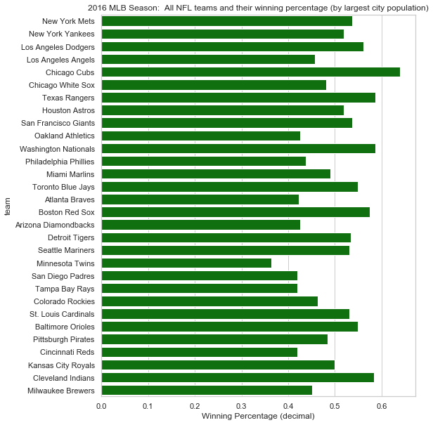

```python
#### Let's take a look at this graphed by WIN_PCT

sns.set(style="whitegrid")
plt.figure(figsize=(8,10))
ax = sns.barplot(x=mlb2['WIN_PCT'], y=mlb2['team'], color='green')
ax.set_title('2016 MLB Season:  All NFL teams and their winning percentage (by largest city population)')
ax.set_xlabel('Winning Percentage (decimal)');

# Look closely:  This is all the teams organized in order of Metro Population ! ! ! ! ! !
#                You can thus get an idea IF visually you see that larger cities have higher percentages ! ! !
```

- What i find interesting here is that in baseball, you usually don't see a team that is crushing everyone else in the league, everyone is tightly close together in terms of overall winning percentage...

```python
def mlb_correlation(): # worth 20% of the assignment grade
    population_by_region = mlb2.Population # pass in metropolitan area population from cities
    win_loss_by_region = mlb2.WIN_PCT      # pass in win/loss ratio from nfl_df in the same order as cities["Metropolitan area"]
    return stats.pearsonr(population_by_region, win_loss_by_region)

mlb_correlation()
```

```
(0.24255747441627393, 0.19653799731000599)
```

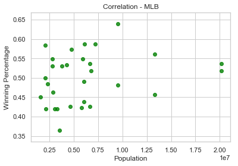

```python
#---  EXAMINING THE MLB DATA SCATTER PLOT  ---

x = mlb2.Population
y = mlb2.WIN_PCT
plt.scatter(x, y, c='green', alpha=.8)
plt.title("Correlation - MLB")
plt.xlabel("Population")
plt.ylabel("Winning Percentage")
plt.show();
```

**Thoughts:** * As the population increases, there appears to be a slight increase in winning percentage (within reason) * .243 tells the story there is somewhat of a positive linear relationship, which I would classify as 'weak'...

### - NHL:

```python
#  d4 is the previously created dictionary to map NBA teams to Metro Areas
```

```python
#---  f_nhl is the consolidated team and WIN_PCT for that nhl team
nhl2 = f_nhl.copy()
nhl2['Nickname'] = f_nhl['team'].apply(lambda x: x.split()[-1]).copy()
nhl2.replace({'Leafs': 'Maple Leafs','Jackets': 'Blue Jackets','Wings': 'Red Wings'}, inplace=True);

#---  MAP THE TEAM NICKNAME TO THE METRO AREA IT IS ASSOCIATED WITH  ---
nhl2['MSO'] = nhl2['Nickname'].map(d4)

#---  The Population value is now to be mapped appropriated (associated with correct METRO)
nhl2['Population'] = nhl2.MSO.map(metro_to_pop_DB)

nhl2.sort_values('Population', ascending=False, inplace=True)#  Show based on descending population
nhl2.reset_index(inplace=True, drop=True)#  resetting index

display(HTML(nhl2.to_html(index=False)))

#  THIS IS OUR LAST SPORT DATASET
#  VERY GOOD INFORMATION AND SHOWS TRUE UNDERSTANDING OF PANDAS COMMANDS
#  Note:  See how top two metro areas (NY and LA) actually have FIVE NHL teams ????
#         At least now you have the per team actual breakout !
```

| team | WIN_PCT | Nickname | MSO | Population |
| --- | --- | --- | --- | --- |
| New York Islanders | 0.6250 | Islanders | New York City | 20,153,634.0000 |
| New York Rangers | 0.6301 | Rangers | New York City | 20,153,634.0000 |
| New Jersey Devils | 0.5135 | Devils | New York City | 20,153,634.0000 |
| Los Angeles Kings | 0.6316 | Kings | Los Angeles | 13,310,447.0000 |
| Anaheim Ducks | 0.6479 | Ducks | Los Angeles | 13,310,447.0000 |
| Chicago Blackhawks | 0.6438 | Blackhawks | Chicago | 9,512,999.0000 |
| Dallas Stars | 0.6849 | Stars | Dallas–Fort Worth | 7,233,323.0000 |
| San Jose Sharks | 0.6053 | Sharks | San Francisco Bay Area | 6,657,982.0000 |
| Washington Capitals | 0.7568 | Capitals | Washington, D.C. | 6,131,977.0000 |
| Philadelphia Flyers | 0.6029 | Flyers | Philadelphia | 6,070,500.0000 |
| Florida Panthers | 0.6438 | Panthers | Miami–Fort Lauderdale | 6,066,387.0000 |
| Toronto Maple Leafs | 0.4085 | Maple Leafs | Toronto | 5,928,040.0000 |
| Boston Bruins | 0.5753 | Bruins | Boston | 4,794,447.0000 |
| Arizona Coyotes | 0.4730 | Coyotes | Phoenix | 4,661,537.0000 |
| Detroit Red Wings | 0.5775 | Red Wings | Detroit | 4,297,617.0000 |
| Montreal Canadiens | 0.5000 | Canadiens | Montreal | 4,098,927.0000 |
| Minnesota Wild | 0.5352 | Wild | Minneapolis–Saint Paul | 3,551,036.0000 |
| Tampa Bay Lightning | 0.5974 | Lightning | Tampa Bay Area | 3,032,171.0000 |
| Colorado Avalanche | 0.5000 | Avalanche | Denver | 2,853,077.0000 |
| St. Louis Blues | 0.6712 | Blues | St. Louis | 2,807,002.0000 |
| Vancouver Canucks | 0.4493 | Canucks | Vancouver | 2,463,431.0000 |
| Pittsburgh Penguins | 0.6486 | Penguins | Pittsburgh | 2,342,299.0000 |
| Columbus Blue Jackets | 0.4595 | Blue Jackets | Columbus | 2,041,520.0000 |
| Nashville Predators | 0.6029 | Predators | Nashville | 1,865,298.0000 |
| Calgary Flames | 0.4667 | Flames | Calgary | 1,392,609.0000 |
| Ottawa Senators | 0.5205 | Senators | Ottawa | 1,323,783.0000 |
| Edmonton Oilers | 0.4189 | Oilers | Edmonton | 1,321,426.0000 |
| Carolina Hurricanes | 0.5303 | Hurricanes | Raleigh | 1,302,946.0000 |
| Buffalo Sabres | 0.4930 | Sabres | Buffalo | 1,132,804.0000 |
| Winnipeg Jets | 0.4730 | Jets | Winnipeg | 778,489.0000 |

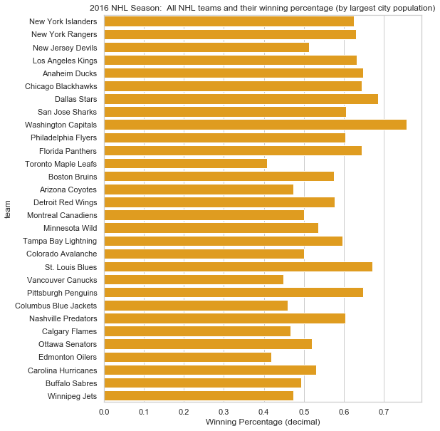

```python
#### Let's take a look at this graphed by WIN_PCT

sns.set(style="whitegrid")
plt.figure(figsize=(8,10))
ax = sns.barplot(x=nhl2['WIN_PCT'], y=nhl2['team'], color='orange')
ax.set_title('2016 NHL Season:  All NHL teams and their winning percentage (by largest city population)')
ax.set_xlabel('Winning Percentage (decimal)');

# Look closely:  This is all the teams organized in order of Metro Population ! ! ! ! ! !
#                You can thus get an idea IF visually you see that larger cities have higher percentages ! ! !
```

```python
def nhl_correlation():
    population_by_region = nhl2.Population
    win_loss_by_region = nhl2.WIN_PCT
    return stats.pearsonr(population_by_region, win_loss_by_region)

nhl_correlation()
```

```
(0.3668960780642693, 0.04611397475223819)
```

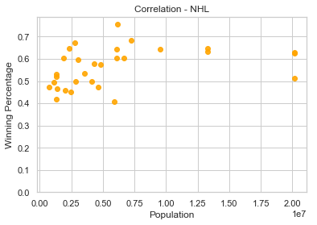

```python
#---  EXAMINING THE MLB DATA SCATTER PLOT  ---
x = nhl2.Population
y = nhl2.WIN_PCT
plt.scatter(x, y, c='orange', alpha=.9)
plt.title("Correlation - NHL")
plt.xlabel("Population")
plt.ylabel("Winning Percentage")
plt.ylim(0)
plt.show();
```

**Thoughts:** * As the population increases, there appears to be an increase in winning percentage * .367 tells the story there is a linear relationship...and I would classify this as a 'moderate positive linear relationship'

# - - - - - - - - - - - - - - - - - - - S T O P - - - - - - - - - - - - - - - - - - - - - - - - - - -

# 1b)

### I'm going to do the *ENTIRE* assignment over, because I did not know precisely what to do for cities that had multiple teams per individual sport.

#### This time I will assume we want to **consolidate all data about all teams that share the Metro Area and also same actual sport**

In other words: This time i will repeat all of the above steps I have taken, BUT i will AVERAGE the individual sports teams if they are the same sport associated with the same metropolitan area ! This way we will have ONE unified WIN_PCT value with EACH independent metropolitan area...

```python
#  Average the win/loss ratios for those cities which have multiple teams of a single sport.
```

```python
#---  IMPORTING LIBRARIES  ---

import pandas as pd
import numpy as np
import html5lib
import requests
import scipy.stats as stats
import re
from bs4 import BeautifulSoup
from IPython.core.interactiveshell import InteractiveShell
from IPython.display import display, HTML
InteractiveShell.ast_node_interactivity = "all"
pd.set_option('display.max_rows', 500)
import matplotlib.pyplot as plt
%matplotlib inline
import seaborn as sns

def sh(input):
    return display(input)
```

#### Building Core Metro/Cities Dataframe:

```python
#---  READ IN THE HTML DATA FILE OF METRO REGIONS AND SPORTS TEAMS  ---
cities=pd.read_html("assets/wikipedia_data.html")[1]

#---  ONLY USE CERTAIN COLUMNS LIKE THE METRO AREA, POPULATION, AND BIG FOUR SPORTS  ---
cities=cities.iloc[:-1,[0,3,5,6,7,8]]  #  removing last row which is just totals info
```

```python
#------------------------------[CLEANING]-------------------------------------
cities.replace(to_replace="\[.*\]", value='', inplace=True, regex=True)#  kill bracketed info
cities.replace(to_replace="—", value='', inplace=True, regex=True)#       kill dashes

#---  CHANGE COLUMN NAMES  ---
cities.rename(columns={cities.columns[1]: "POP"}, inplace=True)#    clean approach
cities.rename(columns={cities.columns[0]: "METRO"}, inplace=True)#  clean approach

#---  CONVERT POPULATION COLUMN TO AN INTEGER DTYPE  ---
cities.POP   =   cities['POP'].astype(float)

#---  STRIP WHITESPACES JUST TO BE SAFE  ---
cities.METRO  =  cities.METRO.str.strip()
cities.NFL    =  cities.NFL.str.strip()
cities.MLB    =  cities.MLB.str.strip()
cities.NBA    =  cities.NBA.str.strip()
cities.NHL    =  cities.NHL.str.strip()
#  This time i show you one other way of stripping whitespaces (per column)


sh(cities.head())
```

|  | METRO | POP | NFL | MLB | NBA | NHL |
| --- | --- | --- | --- | --- | --- | --- |
| 0 | New York City | 20,153,634.0000 | GiantsJets | YankeesMets | KnicksNets | RangersIslandersDevils |
| 1 | Los Angeles | 13,310,447.0000 | RamsChargers | DodgersAngels | LakersClippers | KingsDucks |
| 2 | San Francisco Bay Area | 6,657,982.0000 | 49ersRaiders | GiantsAthletics | Warriors | Sharks |
| 3 | Chicago | 9,512,999.0000 | Bears | CubsWhite Sox | Bulls | Blackhawks |
| 4 | Dallas–Fort Worth | 7,233,323.0000 | Cowboys | Rangers | Mavericks | Stars |

#### Let's create the Big-4 sports dataframes:

**NOTE:** The original NHL .csv raw data had the years '2016' mistakenly labelled as '2017', so I needed to work around this...

Note: This is a fundamentally different way of doing things than our first approach. We are going to keep the combined teams as a single entity, and thus EACH Metropolitan area will have ONE and ONLY ONE consolidated team / winning percentage. We will NOT keep each team independent, we will assume multiple teams in the SAME sport in the SAME city should have all of their winning percentages averaged...

```python
#---  CREATING SPORT DATAFRAMES FROM RAW DATA  ---

mlb_df=pd.read_csv("assets/mlb.csv")
nhl_df=pd.read_csv("assets/nhl.csv")
nba_df=pd.read_csv("assets/nba.csv")
nfl_df=pd.read_csv("assets/nfl.csv")


print("\nI deliberately keep the column headers the same for each big 4 sport...")
print("Looking at just the first four rows from each sport:")
print("[Percentages are in decimal form]")

pd.options.display.float_format = '{:,.4f}'.format



#-----------------------------[NFL]-------------------------------------


# OLD information from the very top of this notebook
#
# ##############################################
# #           Clean NFL raw data               #
# ##############################################

# #---  MATCH BASED ON YEAR 2016 AND ON TEAMNAME NOT CONTAINING AFC OR NFC  ---
# cl_nfl_df = nfl_df[  (nfl_df['year']==2016) & (~nfl_df['team'].str.contains('AFC|NFC'))  ].copy()

# #---  REMOVE THE CHARACTER * AND + FROM THE RIGHT HAND SIDE  ---
# cl_nfl_df.team = cl_nfl_df['team'].map(lambda x: x.rstrip('+|*'))

# #clean_nfl_df['team'] = clean_nfl_df['team'].map(lambda x: str(x)[:-1])

# #---  FINAL CLEAN AND CHECK  ---
# cl_nfl_df.team = cl_nfl_df['team'].str.strip()  # just to make sure

# ##############################################
# #           CREATE NFL WIN% DF               #
# ##############################################

# f_nfl_df = cl_nfl_df#   new copy
# f_nfl_df.W = f_nfl_df.W.astype('int64')#   convert column W to type integer
# f_nfl_df.L = f_nfl_df.L.astype('int64')#   convert column L to type integer

# f_nfl_df['WIN_PCT'] = f_nfl_df['W'] / (f_nfl_df['L'] + f_nfl_df['W'])#   create win pct col

# f_nfl = f_nfl_df[ ['team','WIN_PCT']]#   return only specific cols
# f_nfl.reset_index(inplace = True, drop=True)#   reset index to remove old

# sh(f_nfl.head(4))
# #__Note:  32 total nfl teams





##############################################
#           Clean NFL raw data II            #
##############################################

#---  MATCH BASED ON YEAR 2016 AND ON TEAMNAME NOT CONTAINING AFC OR NFC  ---
cl_nfl_df = nfl_df[  (nfl_df['year']==2016) & (~nfl_df['team'].str.contains('AFC|NFC'))  ].copy()

#---  REMOVE THE CHARACTER * AND + FROM THE RIGHT HAND SIDE  ---
cl_nfl_df.team = cl_nfl_df['team'].map(lambda x: x.rstrip('+|*'))

#---  FINAL CLEAN AND CHECK  ---
cl_nfl_df.team = cl_nfl_df['team'].str.strip()  # just to make sure

#  sh(cl_nfl_df)

##############################################
#           CREATE NFL WIN% DF               #
##############################################

f_nfl_df = cl_nfl_df#   new copy
f_nfl_df.W = f_nfl_df.W.astype('int64')#   convert column W to type integer
f_nfl_df.L = f_nfl_df.L.astype('int64')#   convert column L to type integer

f_nfl_df['WIN_PCT'] = f_nfl_df['W'] / (f_nfl_df['L'] + f_nfl_df['W'])#   create win pct col
f_nfl = f_nfl_df[ ['team','WIN_PCT']]#   return only specific cols


# &&&&&&&&&&&&&&&& ADDING A NEW SET OF ROWS &&&&&&&&&&&&&&&&&&&
# GiantsJets      New York City
# RamsChargers    Los Angeles
# 49ersRaiders    San Francisco Bay Area

# Adding  -  GiantsJets particular information:
pct1 = (f_nfl[f_nfl['team'] == 'New York Giants'].WIN_PCT.values[0] + f_nfl[f_nfl['team'] == 'New York Jets'].WIN_PCT.values[0])/2
f_nfl = f_nfl.append({'team':'GiantsJets', 'WIN_PCT':pct1} , ignore_index=True)
f_nfl.drop(f_nfl[f_nfl.team =='New York Jets'].index, inplace=True)
f_nfl.drop(f_nfl[f_nfl.team =='New York Giants'].index, inplace=True)

# Adding  -  RamsChargers particular information:
pct2 = (f_nfl[f_nfl['team'] == 'Los Angeles Rams'].WIN_PCT.values[0] + f_nfl[f_nfl['team'] == 'San Diego Chargers'].WIN_PCT.values[0])/2
f_nfl = f_nfl.append({'team':'RamsChargers', 'WIN_PCT':pct2} , ignore_index=True)
f_nfl.drop(f_nfl[f_nfl.team =='Los Angeles Rams'].index, inplace=True)
f_nfl.drop(f_nfl[f_nfl.team =='San Diego Chargers'].index, inplace=True)

# Adding  -  49ersRaiders particular information:
pct3 = (f_nfl[f_nfl['team'] == 'San Francisco 49ers'].WIN_PCT.values[0] + f_nfl[f_nfl['team'] == 'Oakland Raiders'].WIN_PCT.values[0])/2
f_nfl = f_nfl.append({'team':'49ersRaiders', 'WIN_PCT':pct3} , ignore_index=True)
f_nfl.drop(f_nfl[f_nfl.team =='San Francisco 49ers'].index, inplace=True)
f_nfl.drop(f_nfl[f_nfl.team =='Oakland Raiders'].index, inplace=True)

f_nfl.reset_index(inplace = True, drop=True)
# &&&&&&&&&&&&&&&&&&&&&&&&&&&&&&&&&&&&&&&&&&&&&&&&&&&&&&&&&&&&&




#-----------------------------[NBA]-------------------------------------

##############################################
#           Clean NBA raw data               #
##############################################

#---   MATCH BASED ON YEAR 2016   ---
cl_nba_df = nba_df[ nba_df['year']==2016 ].copy()

#---  USE YOUR BRAIN AND THINK OF TIGHT REGEX VERSUS ARCHAIC REMOVAL  ---
cl_nba_df['team'] = cl_nba_df['team'].str.extract(r'([A-Z].*[a-z])', expand=False)

#---  FINAL CLEAN AND CHECK  ---
cl_nba_df.team = cl_nba_df['team'].str.strip()  # just to make sure

##############################################
#           Create NBA win% df               #
##############################################

f_nba_df = cl_nba_df

f_nba_df.W = f_nba_df.W.astype('int64')
f_nba_df.L = f_nba_df.L.astype('int64')

f_nba_df['WIN_PCT'] = f_nba_df['W'] / (f_nba_df['L'] + f_nba_df['W'])

f_nba = f_nba_df[ ['team','WIN_PCT']]


# # &&&&&&&&&&&&&&&& ADDING A NEW SET OF ROWS &&&&&&&&&&&&&&&&&&&
# # KnicksNets       New York City
# # LakersClippers   Los Angeles

# Adding  -  KnicksNets particular information:
pct4 = (f_nba[f_nba['team'] == 'New York Knicks'].WIN_PCT.values[0] + f_nba[f_nba['team'] == 'Brooklyn Nets'].WIN_PCT.values[0])/2
f_nba = f_nba.append({'team':'KnicksNets', 'WIN_PCT':pct4} , ignore_index=True)
f_nba.drop(f_nba[f_nba.team =='New York Knicks'].index, inplace=True)
f_nba.drop(f_nba[f_nba.team =='Brooklyn Nets'].index, inplace=True)

# Adding  -  LakersClippers particular information:
pct5 = (f_nba[f_nba['team'] == 'Los Angeles Lakers'].WIN_PCT.values[0] + f_nba[f_nba['team'] == 'Los Angeles Clippers'].WIN_PCT.values[0])/2
f_nba = f_nba.append({'team':'LakersClippers', 'WIN_PCT':pct5} , ignore_index=True)
f_nba.drop(f_nba[f_nba.team =='Los Angeles Clippers'].index, inplace=True)
f_nba.drop(f_nba[f_nba.team =='Los Angeles Lakers'].index, inplace=True)

f_nba.reset_index(inplace = True, drop=True)#   reset index to remove old
# # &&&&&&&&&&&&&&&&&&&&&&&&&&&&&&&&&&&&&&&&&&&&&&&&&&&&&&&&&&&&&

# sh(f_nba.head())




#-----------------------------[MLB]-------------------------------------

##############################################
#           Clean MLB raw data               #
##############################################

#---  MATCH BASED ON YEAR 2016  ---
cl_mlb_df = mlb_df[mlb_df['year']==2016].copy()

#---  FINAL CLEAN AND CHECK  ---
cl_mlb_df.team = cl_mlb_df['team'].str.strip()

##############################################
#           Create MLB win% df               #
##############################################

f_mlb_df = cl_mlb_df

f_mlb_df.W = f_mlb_df.W.astype('int64')
f_mlb_df.L = f_mlb_df.L.astype('int64')

f_mlb_df['WIN_PCT'] = f_mlb_df['W'] / (f_mlb_df['L'] + f_mlb_df['W'])

f_mlb = f_mlb_df[ ['team','WIN_PCT']]


# # &&&&&&&&&&&&&&&& ADDING A NEW SET OF ROWS &&&&&&&&&&&&&&&&&&&

# Adding  -  YankeesMets particular information:
pct6 = (f_mlb[f_mlb['team'] == 'New York Mets'].WIN_PCT.values[0] + f_mlb[f_mlb['team'] == 'New York Yankees'].WIN_PCT.values[0])/2
f_mlb = f_mlb.append({'team':'YankeesMets', 'WIN_PCT':pct6} , ignore_index=True)
f_mlb.drop(f_mlb[f_mlb.team =='New York Mets'].index, inplace=True)
f_mlb.drop(f_mlb[f_mlb.team =='New York Yankees'].index, inplace=True)

# Adding  -  DodgersAngels particular information:
pct7 = (f_mlb[f_mlb['team'] == 'Los Angeles Dodgers'].WIN_PCT.values[0] + f_mlb[f_mlb['team'] == 'Los Angeles Angels'].WIN_PCT.values[0])/2
f_mlb = f_mlb.append({'team':'DodgersAngels', 'WIN_PCT':pct7} , ignore_index=True)
f_mlb.drop(f_mlb[f_mlb.team =='Los Angeles Dodgers'].index, inplace=True)
f_mlb.drop(f_mlb[f_mlb.team =='Los Angeles Angels'].index, inplace=True)

# Adding  -  GiantsAthletics particular information:
pct8 = (f_mlb[f_mlb['team'] == 'Oakland Athletics'].WIN_PCT.values[0] + f_mlb[f_mlb['team'] == 'San Francisco Giants'].WIN_PCT.values[0])/2
f_mlb = f_mlb.append({'team':'GiantsAthletics', 'WIN_PCT':pct8} , ignore_index=True)
f_mlb.drop(f_mlb[f_mlb.team =='San Francisco Giants'].index, inplace=True)
f_mlb.drop(f_mlb[f_mlb.team =='Oakland Athletics'].index, inplace=True)

# Adding  -  CubsWhite Sox particular information:
pct9 = (f_mlb[f_mlb['team'] == 'Chicago Cubs'].WIN_PCT.values[0] + f_mlb[f_mlb['team'] == 'Chicago White Sox'].WIN_PCT.values[0])/2
f_mlb = f_mlb.append({'team':'CubsWhite Sox', 'WIN_PCT':pct9} , ignore_index=True)
f_mlb.drop(f_mlb[f_mlb.team =='Chicago Cubs'].index, inplace=True)
f_mlb.drop(f_mlb[f_mlb.team =='Chicago White Sox'].index, inplace=True)

f_mlb.reset_index(inplace = True, drop=True)
# # &&&&&&&&&&&&&&&&&&&&&&&&&&&&&&&&&&&&&&&&&&&&&&&&&&&&&&&&&&&&&


# sh(f_mlb.head())




#-----------------------------[NHL]-------------------------------------

##############################################
#           Clean NHL raw data               #
##############################################

#---  MATCH BASED ON YEAR 2017  ---
#---  (then reduce back to true 2016)  ---
cl_nhl_df = nhl_df[nhl_df['year']==2017].copy()


#---  IF TEAM CONTAINS 'Division' THEN REMOVE IT  ---
cl_nhl_df =  cl_nhl_df[~cl_nhl_df.team.str.contains("Division")]


#---  REMOVE THE CHARACTER * FROM THE RIGHT HAND SIDE  ---
cl_nhl_df.team = cl_nhl_df['team'].map(lambda x: x.rstrip('*'))


#---  FINAL CLEAN AND CHECK  ---
cl_nhl_df.team = cl_nhl_df['team'].str.strip()
#  sh(cl_nhl_df.team)

##############################################
#           Create NHL win% df               #
##############################################

f_nhl_df = cl_nhl_df

f_nhl_df.W = f_nhl_df.W.astype('int64')
f_nhl_df.L = f_nhl_df.L.astype('int64')

f_nhl_df['WIN_PCT'] = f_nhl_df['W'] / (f_nhl_df['L'] + f_nhl_df['W'])

f_nhl = f_nhl_df[ ['team','WIN_PCT']][-30:]


# # &&&&&&&&&&&&&&&& ADDING A NEW SET OF ROWS &&&&&&&&&&&&&&&&&&&

# RangersIslandersDevils
# KingsDucks

#  Adding  -  RangersIslandersDevils particular information:   (careful, its three teams !)
pct10 = (f_nhl[f_nhl['team'] == 'New York Rangers'].WIN_PCT.values[0] + f_nhl[f_nhl['team'] == 'New York Islanders'].WIN_PCT.values[0] + f_nhl[f_nhl['team'] == 'New York Rangers'].WIN_PCT.values[0])/3
f_nhl = f_nhl.append({'team':'RangersIslandersDevils', 'WIN_PCT':pct10} , ignore_index=True)
f_nhl.drop(f_nhl[f_nhl.team =='New York Rangers'].index, inplace=True)
f_nhl.drop(f_nhl[f_nhl.team =='New York Islanders'].index, inplace=True)
f_nhl.drop(f_nhl[f_nhl.team =='New Jersey Devils'].index, inplace=True)

#  Adding  -  RangersIslandersDevils particular information:
pct11 = (f_nhl[f_nhl['team'] == 'Los Angeles Kings'].WIN_PCT.values[0] + f_nhl[f_nhl['team'] == 'Anaheim Ducks'].WIN_PCT.values[0] )/2
f_nhl = f_nhl.append({'team':'KingsDucks', 'WIN_PCT':pct11} , ignore_index=True)
f_nhl.drop(f_nhl[f_nhl.team =='Los Angeles Kings'].index, inplace=True)
f_nhl.drop(f_nhl[f_nhl.team =='Anaheim Ducks'].index, inplace=True)

f_nhl.reset_index(inplace = True, drop=True)#   reset index to remove old
# # &&&&&&&&&&&&&&&&&&&&&&&&&&&&&&&&&&&&&&&&&&&&&&&&&&&&&&&&&&&&&


#sh(f_nhl.head(10))   #__Note:  30 total nhl teams (but after 2016 it was actually 31)
```

```
I deliberately keep the column headers the same for each big 4 sport...
Looking at just the first four rows from each sport:
[Percentages are in decimal form]
```

#### We will need to create a dictionary of Teamname => to Metro area (across all sports):

#### Creating first df (NFL) for mapping

```python
#---    CREATING FOUR DFS, MAPPING A TEAM WITH A METRO AREA  ---
#     (THEN MERGE THEM, CONVERT TO A DICTIONARY, TO USE AS A MAPPER)
#   (YOU COULD ALSO KEEP THEM SEPARATE TO USE INDIVIDUALLY PER SPORT IF YOU WANTED)

# df.set_index('A').to_dict()['B']
#cities.Series(df.Letter.values,index=df.Position).to_dict()
#dict(zip(cities.NFL, cities.Metro))

t1 = cities[['NFL','METRO']].copy()

t1 = t1[t1.NFL != ''].reset_index(drop=True)

t1.METRO = t1.METRO.str.strip()

t1 = t1.reset_index(drop=True)  #  THIS IS NOW A TRUE MAPPER FOR NFL TEAMS TO METRO AREAS

sh(t1)  # maps from the team name over to the METRO location...
#         -  keeping the combined team names

#  SEE THE TWO THREE ROWS ?  SEE HOW THEY ARE COMBINED TEAMS ASSOCIATED WITH A SINGLE METRO AREA ?  THAT IS GOOD !
```

|  | NFL | METRO |
| --- | --- | --- |
| 0 | GiantsJets | New York City |
| 1 | RamsChargers | Los Angeles |
| 2 | 49ersRaiders | San Francisco Bay Area |
| 3 | Bears | Chicago |
| 4 | Cowboys | Dallas–Fort Worth |
| 5 | Redskins | Washington, D.C. |
| 6 | Eagles | Philadelphia |
| 7 | Patriots | Boston |
| 8 | Vikings | Minneapolis–Saint Paul |
| 9 | Broncos | Denver |
| 10 | Dolphins | Miami–Fort Lauderdale |
| 11 | Cardinals | Phoenix |
| 12 | Lions | Detroit |
| 13 | Texans | Houston |
| 14 | Falcons | Atlanta |
| 15 | Buccaneers | Tampa Bay Area |
| 16 | Steelers | Pittsburgh |
| 17 | Browns | Cleveland |
| 18 | Seahawks | Seattle |
| 19 | Bengals | Cincinnati |
| 20 | Chiefs | Kansas City |
| 21 | Ravens | Baltimore |
| 22 | Panthers | Charlotte |
| 23 | Colts | Indianapolis |
| 24 | Titans | Nashville |
| 25 | Saints | New Orleans |
| 26 | Bills | Buffalo |
| 27 | Jaguars | Jacksonville |
| 28 | Packers | Green Bay |

#### Creating second df (NBA) for mapping

```python
#  cities[['NBA','METRO']]
```

```python
t2 = cities[['NBA','METRO']].copy()

t2 = t2[t2.NBA != ''].reset_index(drop=True)

t2.METRO = t2.METRO.str.strip()

t2 = t2.reset_index(drop=True)
#  THIS IS NOW A TRUE MAPPER FOR NBA TEAMS TO METRO AREAS

sh(t2)

#  Yep, we see two top teams associated with the top two Metro areas... as we want.
```

|  | NBA | METRO |
| --- | --- | --- |
| 0 | KnicksNets | New York City |
| 1 | LakersClippers | Los Angeles |
| 2 | Warriors | San Francisco Bay Area |
| 3 | Bulls | Chicago |
| 4 | Mavericks | Dallas–Fort Worth |
| 5 | Wizards | Washington, D.C. |
| 6 | 76ers | Philadelphia |
| 7 | Celtics | Boston |
| 8 | Timberwolves | Minneapolis–Saint Paul |
| 9 | Nuggets | Denver |
| 10 | Heat | Miami–Fort Lauderdale |
| 11 | Suns | Phoenix |
| 12 | Pistons | Detroit |
| 13 | Raptors | Toronto |
| 14 | Rockets | Houston |
| 15 | Hawks | Atlanta |
| 16 | Cavaliers | Cleveland |
| 17 | Hornets | Charlotte |
| 18 | Pacers | Indianapolis |
| 19 | Bucks | Milwaukee |
| 20 | Pelicans | New Orleans |
| 21 | Magic | Orlando |
| 22 | Trail Blazers | Portland |
| 23 | Jazz | Salt Lake City |
| 24 | Spurs | San Antonio |
| 25 | Kings | Sacramento |
| 26 | Thunder | Oklahoma City |
| 27 | Grizzlies | Memphis |

#### Creating third df (MLB) for mapping

```python
t3 = cities[['MLB','METRO']].copy()

t3 = t3[t3.MLB != ''].reset_index(drop=True)

t3.METRO = t3.METRO.str.strip()

t3 = t3.reset_index(drop=True)  # THIS IS NOW A TRUE MAPPER FOR MLB TEAMS TO METRO AREAS

sh(t3)

# this one was hard, i had to have four total pairs of teams associated with four sep metro areas...
```

|  | MLB | METRO |
| --- | --- | --- |
| 0 | YankeesMets | New York City |
| 1 | DodgersAngels | Los Angeles |
| 2 | GiantsAthletics | San Francisco Bay Area |
| 3 | CubsWhite Sox | Chicago |
| 4 | Rangers | Dallas–Fort Worth |
| 5 | Nationals | Washington, D.C. |
| 6 | Phillies | Philadelphia |
| 7 | Red Sox | Boston |
| 8 | Twins | Minneapolis–Saint Paul |
| 9 | Rockies | Denver |
| 10 | Marlins | Miami–Fort Lauderdale |
| 11 | Diamondbacks | Phoenix |
| 12 | Tigers | Detroit |
| 13 | Blue Jays | Toronto |
| 14 | Astros | Houston |
| 15 | Braves | Atlanta |
| 16 | Rays | Tampa Bay Area |
| 17 | Pirates | Pittsburgh |
| 18 | Indians | Cleveland |
| 19 | Mariners | Seattle |
| 20 | Reds | Cincinnati |
| 21 | Royals | Kansas City |
| 22 | Cardinals | St. Louis |
| 23 | Orioles | Baltimore |
| 24 | Brewers | Milwaukee |
| 25 | Padres | San Diego |

#### Creating fourth df (NHL) for mapping

```python
t4 = cities[['NHL','METRO']].copy()

t4 = t4[t4.NHL != ''].reset_index(drop=True)  # remove rows with missing teams
t4 = t4[t4.NHL != 'Golden Knights'] # important to remove !

t4.METRO = t4.METRO.str.strip()

t4 = t4.reset_index(drop=True) #  THIS IS NOW A TRUE MAPPER FOR NHL TEAMS TO METRO AREAS

sh(t4)
```

|  | NHL | METRO |
| --- | --- | --- |
| 0 | RangersIslandersDevils | New York City |
| 1 | KingsDucks | Los Angeles |
| 2 | Sharks | San Francisco Bay Area |
| 3 | Blackhawks | Chicago |
| 4 | Stars | Dallas–Fort Worth |
| 5 | Capitals | Washington, D.C. |
| 6 | Flyers | Philadelphia |
| 7 | Bruins | Boston |
| 8 | Wild | Minneapolis–Saint Paul |
| 9 | Avalanche | Denver |
| 10 | Panthers | Miami–Fort Lauderdale |
| 11 | Coyotes | Phoenix |
| 12 | Red Wings | Detroit |
| 13 | Maple Leafs | Toronto |
| 14 | Lightning | Tampa Bay Area |
| 15 | Penguins | Pittsburgh |
| 16 | Blues | St. Louis |
| 17 | Predators | Nashville |
| 18 | Sabres | Buffalo |
| 19 | Canadiens | Montreal |
| 20 | Canucks | Vancouver |
| 21 | Blue Jackets | Columbus |
| 22 | Flames | Calgary |
| 23 | Senators | Ottawa |
| 24 | Oilers | Edmonton |
| 25 | Jets | Winnipeg |
| 26 | Hurricanes | Raleigh |

#### Now let's create a series of dictionaries to allow easy mapping

```python
d1 = t1.set_index('NFL').to_dict()['METRO']
d2 = t2.set_index('NBA').to_dict()['METRO']
d3 = t3.set_index('MLB').to_dict()['METRO']
d4 = t4.set_index('NHL').to_dict()['METRO']
```

## So let's close the deal here:

### - NFL:

#### Note: See how the dictionary now maps the COMBINED sport teams (single sport) to a single Metro area ? This is entire point...

```python
#---  d1 is a dictionary that maps nfl teams to the metro city  ---

print("Nicely created dictionary (UPDATED) we will use to map the NFL team to the Metro Area: ")
sh(d1)

#  You see the things like:  `49ersRaiders` ?  That is key here...
```

```
Nicely created dictionary (UPDATED) we will use to map the NFL team to the Metro Area:
```

```
{'49ersRaiders': 'San Francisco Bay Area',
 'Bears': 'Chicago',
 'Bengals': 'Cincinnati',
 'Bills': 'Buffalo',
 'Broncos': 'Denver',
 'Browns': 'Cleveland',
 'Buccaneers': 'Tampa Bay Area',
 'Cardinals': 'Phoenix',
 'Chiefs': 'Kansas City',
 'Colts': 'Indianapolis',
 'Cowboys': 'Dallas–Fort Worth',
 'Dolphins': 'Miami–Fort Lauderdale',
 'Eagles': 'Philadelphia',
 'Falcons': 'Atlanta',
 'GiantsJets': 'New York City',
 'Jaguars': 'Jacksonville',
 'Lions': 'Detroit',
 'Packers': 'Green Bay',
 'Panthers': 'Charlotte',
 'Patriots': 'Boston',
 'RamsChargers': 'Los Angeles',
 'Ravens': 'Baltimore',
 'Redskins': 'Washington, D.C.',
 'Saints': 'New Orleans',
 'Seahawks': 'Seattle',
 'Steelers': 'Pittsburgh',
 'Texans': 'Houston',
 'Titans': 'Nashville',
 'Vikings': 'Minneapolis–Saint Paul'}
```

```python
#---  f_nfl is the consolidated team and WIN_PCT for that nfl team
nfl2 = f_nfl.copy()
nfl2['Nickname'] = f_nfl['team'].apply(lambda x: x.split()[-1]).copy()

#---  MAP THE TEAM NICKNAME TO THE METRO AREA IT IS ASSOCIATED WITH  ---
nfl2['MSO'] = nfl2['Nickname'].map(d1)




#---  Creating map link from metro area to master population  ---
metro_to_pop = cities.loc[:, ['METRO', 'POP']].copy()
#sh(metro_to_pop.head())

#---  Flip it to a dictionary to make it clean  ---
metro_to_pop_DB = metro_to_pop.set_index('METRO').to_dict()['POP']
#  metro_to_pop_DB




#---  The Population value is now to be mapped appropriated (associated with correct METRO)
nfl2['Population'] = nfl2.MSO.map(metro_to_pop_DB)

nfl2.reset_index(inplace=True, drop=True)#  resetting index
nfl2.sort_values('Population', ascending=False, inplace=True)


display(HTML(nfl2.to_html(index=False)))
```

| team | WIN_PCT | Nickname | MSO | Population |
| --- | --- | --- | --- | --- |
| GiantsJets | 0.5000 | GiantsJets | New York City | 20,153,634.0000 |
| RamsChargers | 0.2812 | RamsChargers | Los Angeles | 13,310,447.0000 |
| Chicago Bears | 0.1875 | Bears | Chicago | 9,512,999.0000 |
| Dallas Cowboys | 0.8125 | Cowboys | Dallas–Fort Worth | 7,233,323.0000 |
| Houston Texans | 0.5625 | Texans | Houston | 6,772,470.0000 |
| 49ersRaiders | 0.4375 | 49ersRaiders | San Francisco Bay Area | 6,657,982.0000 |
| Washington Redskins | 0.5333 | Redskins | Washington, D.C. | 6,131,977.0000 |
| Philadelphia Eagles | 0.4375 | Eagles | Philadelphia | 6,070,500.0000 |
| Miami Dolphins | 0.6250 | Dolphins | Miami–Fort Lauderdale | 6,066,387.0000 |
| Atlanta Falcons | 0.6875 | Falcons | Atlanta | 5,789,700.0000 |
| New England Patriots | 0.8750 | Patriots | Boston | 4,794,447.0000 |
| Arizona Cardinals | 0.4667 | Cardinals | Phoenix | 4,661,537.0000 |
| Detroit Lions | 0.5625 | Lions | Detroit | 4,297,617.0000 |
| Seattle Seahawks | 0.6667 | Seahawks | Seattle | 3,798,902.0000 |
| Minnesota Vikings | 0.5000 | Vikings | Minneapolis–Saint Paul | 3,551,036.0000 |
| Tampa Bay Buccaneers | 0.5625 | Buccaneers | Tampa Bay Area | 3,032,171.0000 |
| Denver Broncos | 0.5625 | Broncos | Denver | 2,853,077.0000 |
| Baltimore Ravens | 0.5000 | Ravens | Baltimore | 2,798,886.0000 |
| Carolina Panthers | 0.3750 | Panthers | Charlotte | 2,474,314.0000 |
| Pittsburgh Steelers | 0.6875 | Steelers | Pittsburgh | 2,342,299.0000 |
| Cincinnati Bengals | 0.4000 | Bengals | Cincinnati | 2,165,139.0000 |
| Kansas City Chiefs | 0.7500 | Chiefs | Kansas City | 2,104,509.0000 |
| Cleveland Browns | 0.0625 | Browns | Cleveland | 2,055,612.0000 |
| Indianapolis Colts | 0.5000 | Colts | Indianapolis | 2,004,230.0000 |
| Tennessee Titans | 0.5625 | Titans | Nashville | 1,865,298.0000 |
| Jacksonville Jaguars | 0.1875 | Jaguars | Jacksonville | 1,478,212.0000 |
| New Orleans Saints | 0.4375 | Saints | New Orleans | 1,268,883.0000 |
| Buffalo Bills | 0.4375 | Bills | Buffalo | 1,132,804.0000 |
| Green Bay Packers | 0.6250 | Packers | Green Bay | 318,236.0000 |

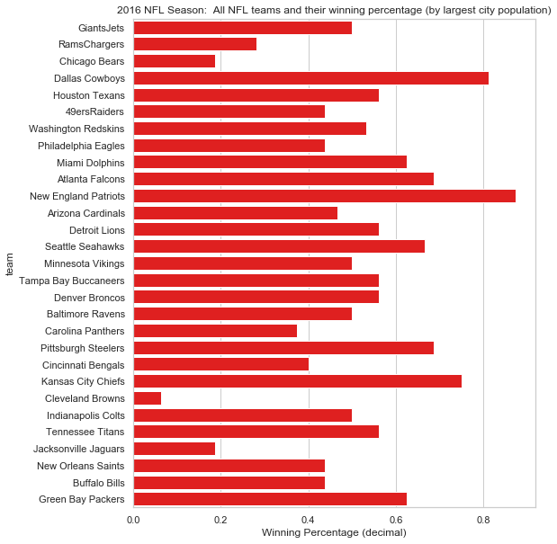

```python
#### Let's take a look at this graphed by WIN_PCT

#  THIS CONTAINS THE COMBINED TEAMS AVERAGED !

sns.set(style="whitegrid")
plt.figure(figsize=(8,10))

ax = sns.barplot(x=nfl2['WIN_PCT'], y=nfl2['team'], color='red')
ax.set_title('2016 NFL Season:  All NFL teams and their winning percentage (by largest city population)')
ax.set_xlabel('Winning Percentage (decimal)');
```

```python
def nfl_correlation():
    population_by_region = nfl2.Population # pass in metropolitan area population from cities
    win_loss_by_region = nfl2.WIN_PCT      # pass in win/loss ratio from nfl_df in the same order as cities["Metropolitan area"]
    return stats.pearsonr(population_by_region, win_loss_by_region)

nfl_correlation()
```

```
(-0.06221175680784657, 0.7485176122800998)
```

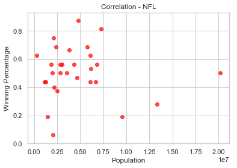

```python
#---  EXAMINING THE NFL DATA SCATTER PLOT  ---
x = nfl2.Population
y = nfl2.WIN_PCT
plt.scatter(x, y, c='red', alpha=.7)
plt.title("Correlation - NFL")
plt.xlabel("Population")
plt.ylabel("Winning Percentage")
#, s=area, c=colors, alpha=0.5)
#  plt.scatter(x, y, s=area, c=colors, alpha=0.5)
plt.ylim(0)
plt.show();
```

**Thoughts:** * x-axis = Metro Population, y-axis = Winning Percentage * As the population increases, there does not appear to be any correlation * Need to be aware that using this function, it is generally assumped that each dataset is normally distributed, and in our case it isnt that normally distributed in general... * https://en.wikipedia.org/wiki/Pearson_correlation_coefficient

[figure not shown]

### - NBA:

```python
#  d2 is the previously created dictionary to map NBA teams to Metro Areas
```

```python
#---  f_nba is the consolidated team and WIN_PCT for that nba team
#---  Add nickname of the last word of the team  ---
nba2 = f_nba.copy()
nba2['Nickname'] = f_nba['team'].apply(lambda x: x.split()[-1]).copy()
nba2.replace({'Blazers': 'Trail Blazers'}, inplace=True)

#---  MAP THE TEAM NICKNAME TO THE METRO AREA IT IS ASSOCIATED WITH  ---
nba2['MSO'] = nba2['Nickname'].map(d2)

#---  Creating map link from metro area to master population  ---
#  already exists from earlier:  metro_to_pop = cities.loc[:, ['METRO', 'POP']].copy()
#  already exists from earlier:  metro_to_pop_DB = metro_to_pop.set_index('METRO').to_dict()['POP']

#---  The Population value is now to be mapped appropriated (associated with correct METRO)
nba2['Population'] = nba2.MSO.map(metro_to_pop_DB)

nba2.reset_index(inplace=True, drop=True)#  resetting index
nba2.sort_values('Population', ascending=False, inplace=True)

display(HTML(nba2.to_html(index=False)))
```

| team | WIN_PCT | Nickname | MSO | Population |
| --- | --- | --- | --- | --- |
| KnicksNets | 0.3232 | KnicksNets | New York City | 20,153,634.0000 |
| LakersClippers | 0.4268 | LakersClippers | Los Angeles | 13,310,447.0000 |
| Chicago Bulls | 0.5122 | Bulls | Chicago | 9,512,999.0000 |
| Dallas Mavericks | 0.5122 | Mavericks | Dallas–Fort Worth | 7,233,323.0000 |
| Houston Rockets | 0.5000 | Rockets | Houston | 6,772,470.0000 |
| Golden State Warriors | 0.8902 | Warriors | San Francisco Bay Area | 6,657,982.0000 |
| Washington Wizards | 0.5000 | Wizards | Washington, D.C. | 6,131,977.0000 |
| Philadelphia 76ers | 0.1220 | 76ers | Philadelphia | 6,070,500.0000 |
| Miami Heat | 0.5854 | Heat | Miami–Fort Lauderdale | 6,066,387.0000 |
| Toronto Raptors | 0.6829 | Raptors | Toronto | 5,928,040.0000 |
| Atlanta Hawks | 0.5854 | Hawks | Atlanta | 5,789,700.0000 |
| Boston Celtics | 0.5854 | Celtics | Boston | 4,794,447.0000 |
| Phoenix Suns | 0.2805 | Suns | Phoenix | 4,661,537.0000 |
| Detroit Pistons | 0.5366 | Pistons | Detroit | 4,297,617.0000 |
| Minnesota Timberwolves | 0.3537 | Timberwolves | Minneapolis–Saint Paul | 3,551,036.0000 |
| Denver Nuggets | 0.4024 | Nuggets | Denver | 2,853,077.0000 |
| Charlotte Hornets | 0.5854 | Hornets | Charlotte | 2,474,314.0000 |
| Orlando Magic | 0.4268 | Magic | Orlando | 2,441,257.0000 |
| San Antonio Spurs | 0.8171 | Spurs | San Antonio | 2,429,609.0000 |
| Portland Trail Blazers | 0.5366 | Trail Blazers | Portland | 2,424,955.0000 |
| Sacramento Kings | 0.4024 | Kings | Sacramento | 2,296,418.0000 |
| Cleveland Cavaliers | 0.6951 | Cavaliers | Cleveland | 2,055,612.0000 |
| Indiana Pacers | 0.5488 | Pacers | Indianapolis | 2,004,230.0000 |
| Milwaukee Bucks | 0.4024 | Bucks | Milwaukee | 1,572,482.0000 |
| Oklahoma City Thunder | 0.6707 | Thunder | Oklahoma City | 1,373,211.0000 |
| Memphis Grizzlies | 0.5122 | Grizzlies | Memphis | 1,342,842.0000 |
| New Orleans Pelicans | 0.3659 | Pelicans | New Orleans | 1,268,883.0000 |
| Utah Jazz | 0.4878 | Jazz | Salt Lake City | 1,186,187.0000 |

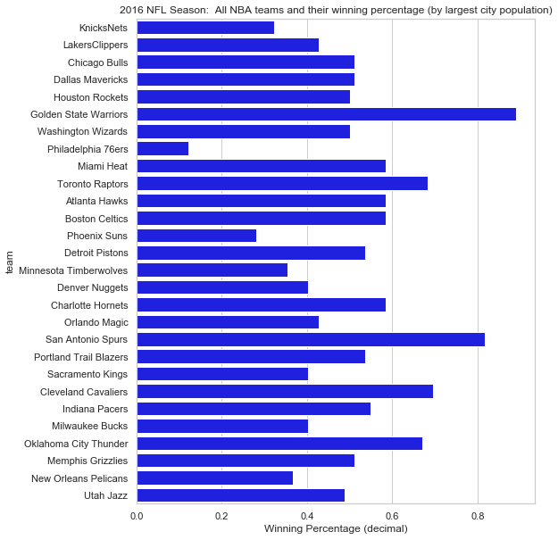

```python
#### Let's take a look at this graphed by WIN_PCT

sns.set(style="whitegrid")
plt.figure(figsize=(8,10))
ax = sns.barplot(x=nba2['WIN_PCT'], y=nba2['team'], color='blue')
ax.set_title('2016 NFL Season:  All NBA teams and their winning percentage (by largest city population)')
ax.set_xlabel('Winning Percentage (decimal)');

# Look closely:  This is all the teams organized in order of Metro Population ! ! ! ! ! !
#                You can thus get an idea IF visually you see that larger cities have higher percentages ! ! !
```

```python
def nba_correlation(): # worth 20% of the assignment grade
    population_by_region = nba2.Population # pass in metropolitan area population from cities
    win_loss_by_region = nba2.WIN_PCT      # pass in win/loss ratio from nba_df in the same order as cities["Metropolitan area"]
    return stats.pearsonr(population_by_region, win_loss_by_region)

nba_correlation()
```

```
(-0.18730545966425097, 0.3398695676323594)
```

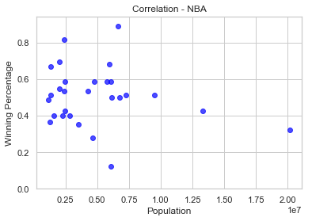

```python
#---  EXAMINING THE NBA DATA SCATTER PLOT  ---
x = nba2.Population
y = nba2.WIN_PCT
plt.scatter(x, y, c='blue', alpha=.7)
plt.title("Correlation - NBA")
plt.xlabel("Population")
plt.ylabel("Winning Percentage")
#, s=area, c=colors, alpha=0.5)
#  plt.scatter(x, y, s=area, c=colors, alpha=0.5)
plt.ylim(0)
plt.show();
```

### - MLB:

```python
#  d3 is the previously created dictionary to map NBA teams to Metro Areas
```

```python
d3
```

```
{'Astros': 'Houston',
 'Blue Jays': 'Toronto',
 'Braves': 'Atlanta',
 'Brewers': 'Milwaukee',
 'Cardinals': 'St. Louis',
 'CubsWhite Sox': 'Chicago',
 'Diamondbacks': 'Phoenix',
 'DodgersAngels': 'Los Angeles',
 'GiantsAthletics': 'San Francisco Bay Area',
 'Indians': 'Cleveland',
 'Mariners': 'Seattle',
 'Marlins': 'Miami–Fort Lauderdale',
 'Nationals': 'Washington, D.C.',
 'Orioles': 'Baltimore',
 'Padres': 'San Diego',
 'Phillies': 'Philadelphia',
 'Pirates': 'Pittsburgh',
 'Rangers': 'Dallas–Fort Worth',
 'Rays': 'Tampa Bay Area',
 'Red Sox': 'Boston',
 'Reds': 'Cincinnati',
 'Rockies': 'Denver',
 'Royals': 'Kansas City',
 'Tigers': 'Detroit',
 'Twins': 'Minneapolis–Saint Paul',
 'YankeesMets': 'New York City'}
```

```python
#---  f_mlb is the consolidated team and WIN_PCT for that mlb team
mlb2 = f_mlb.copy()
mlb2['Nickname'] = f_mlb['team'].apply(lambda x: x.split()[-1]).copy()
mlb2.replace({'Jays': 'Blue Jays'}, inplace=True)
mlb2.iloc[25,2] = 'CubsWhite Sox';  mlb2.iloc[0,2] = 'Red Sox'

#---  MAP THE TEAM NICKNAME TO THE METRO AREA IT IS ASSOCIATED WITH  ---
mlb2['MSO'] = mlb2['Nickname'].map(d3)

mlb2['Population'] = mlb2.MSO.map(metro_to_pop_DB)
#  sh(mlb2.sort_values('Population', ascending=False))

mlb2.reset_index(inplace=True, drop=True)
mlb2.sort_values('Population', ascending=False, inplace=True)
display(HTML(mlb2.to_html(index=False)))
```

| team | WIN_PCT | Nickname | MSO | Population |
| --- | --- | --- | --- | --- |
| YankeesMets | 0.5278 | YankeesMets | New York City | 20,153,634.0000 |
| DodgersAngels | 0.5093 | DodgersAngels | Los Angeles | 13,310,447.0000 |
| CubsWhite Sox | 0.5606 | CubsWhite Sox | Chicago | 9,512,999.0000 |
| Texas Rangers | 0.5864 | Rangers | Dallas–Fort Worth | 7,233,323.0000 |
| Houston Astros | 0.5185 | Astros | Houston | 6,772,470.0000 |
| GiantsAthletics | 0.4815 | GiantsAthletics | San Francisco Bay Area | 6,657,982.0000 |
| Washington Nationals | 0.5864 | Nationals | Washington, D.C. | 6,131,977.0000 |
| Philadelphia Phillies | 0.4383 | Phillies | Philadelphia | 6,070,500.0000 |
| Miami Marlins | 0.4907 | Marlins | Miami–Fort Lauderdale | 6,066,387.0000 |
| Toronto Blue Jays | 0.5494 | Blue Jays | Toronto | 5,928,040.0000 |
| Atlanta Braves | 0.4224 | Braves | Atlanta | 5,789,700.0000 |
| Boston Red Sox | 0.5741 | Red Sox | Boston | 4,794,447.0000 |
| Arizona Diamondbacks | 0.4259 | Diamondbacks | Phoenix | 4,661,537.0000 |
| Detroit Tigers | 0.5342 | Tigers | Detroit | 4,297,617.0000 |
| Seattle Mariners | 0.5309 | Mariners | Seattle | 3,798,902.0000 |
| Minnesota Twins | 0.3642 | Twins | Minneapolis–Saint Paul | 3,551,036.0000 |
| San Diego Padres | 0.4198 | Padres | San Diego | 3,317,749.0000 |
| Tampa Bay Rays | 0.4198 | Rays | Tampa Bay Area | 3,032,171.0000 |
| Colorado Rockies | 0.4630 | Rockies | Denver | 2,853,077.0000 |
| St. Louis Cardinals | 0.5309 | Cardinals | St. Louis | 2,807,002.0000 |
| Baltimore Orioles | 0.5494 | Orioles | Baltimore | 2,798,886.0000 |
| Pittsburgh Pirates | 0.4845 | Pirates | Pittsburgh | 2,342,299.0000 |
| Cincinnati Reds | 0.4198 | Reds | Cincinnati | 2,165,139.0000 |
| Kansas City Royals | 0.5000 | Royals | Kansas City | 2,104,509.0000 |
| Cleveland Indians | 0.5839 | Indians | Cleveland | 2,055,612.0000 |
| Milwaukee Brewers | 0.4506 | Brewers | Milwaukee | 1,572,482.0000 |

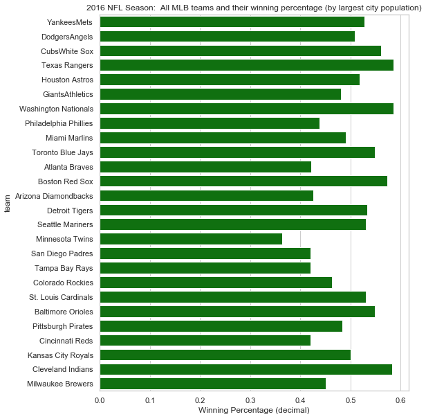

```python
#### Let's take a look at this graphed by WIN_PCT

sns.set(style="whitegrid")
plt.figure(figsize=(8,10))
ax = sns.barplot(x=mlb2['WIN_PCT'], y=mlb2['team'], color='green')
ax.set_title('2016 NFL Season:  All MLB teams and their winning percentage (by largest city population)')
ax.set_xlabel('Winning Percentage (decimal)');

# Look closely:  This is all the teams organized in order of Metro Population ! ! ! ! ! !
#                You can thus get an idea IF visually you see that larger cities have higher percentages ! ! !
```

```python
def mlb_correlation():
    population_by_region = mlb2.Population
    win_loss_by_region = mlb2.WIN_PCT
    return stats.pearsonr(population_by_region, win_loss_by_region)

mlb_correlation()
```

```
(0.24554628030517026, 0.22662980834925986)
```

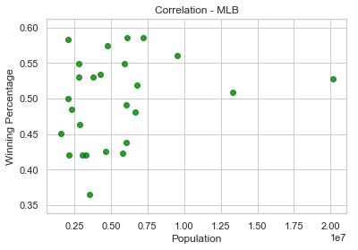

```python
#---  EXAMINING THE MLB DATA SCATTER PLOT  ---
x = mlb2.Population
y = mlb2.WIN_PCT
plt.scatter(x, y, c='green', alpha=.8)
plt.title("Correlation - MLB")
plt.xlabel("Population")
plt.ylabel("Winning Percentage")
# plt.ylim(0)
plt.show();
```

**Thoughts:** * As the population increases, there appears to be a slight increase in winning percentage (within reason) * .246 tells the story there is somewhat of a linear relationship...

### - NHL:

```python
#  d4 is the previously created dictionary to map NBA teams to Metro Areas
```

```python
#---  f_nhl is the consolidated team and WIN_PCT for that nhl team

nhl2 = f_nhl.copy()
nhl2['Nickname'] = f_nhl['team'].apply(lambda x: x.split()[-1]).copy()
nhl2.replace({'Leafs': 'Maple Leafs','Jackets': 'Blue Jackets','Wings': 'Red Wings'}, inplace=True);

#---  MAP THE TEAM NICKNAME TO THE METRO AREA IT IS ASSOCIATED WITH  ---
nhl2['MSO'] = nhl2['Nickname'].map(d4)

#---  The Population value is now to be mapped appropriated (associated with correct METRO)
nhl2['Population'] = nhl2.MSO.map(metro_to_pop_DB)


nhl2.reset_index(inplace=True, drop=True)#  resetting index
nhl2.sort_values('Population', ascending=False, inplace=True)

display(HTML(nhl2.to_html(index=False)))



# TOM:  DOUBLE CHECK YOU AGREE WITH THOSE TOTAL CONSOLIDATED AVERAGED WIN PERCENTAGES ! ! ! ! ! !
```

| team | WIN_PCT | Nickname | MSO | Population |
| --- | --- | --- | --- | --- |
| RangersIslandersDevils | 0.6284 | RangersIslandersDevils | New York City | 20,153,634.0000 |
| KingsDucks | 0.6397 | KingsDucks | Los Angeles | 13,310,447.0000 |
| Chicago Blackhawks | 0.6438 | Blackhawks | Chicago | 9,512,999.0000 |
| Dallas Stars | 0.6849 | Stars | Dallas–Fort Worth | 7,233,323.0000 |
| San Jose Sharks | 0.6053 | Sharks | San Francisco Bay Area | 6,657,982.0000 |
| Washington Capitals | 0.7568 | Capitals | Washington, D.C. | 6,131,977.0000 |
| Philadelphia Flyers | 0.6029 | Flyers | Philadelphia | 6,070,500.0000 |
| Florida Panthers | 0.6438 | Panthers | Miami–Fort Lauderdale | 6,066,387.0000 |
| Toronto Maple Leafs | 0.4085 | Maple Leafs | Toronto | 5,928,040.0000 |
| Boston Bruins | 0.5753 | Bruins | Boston | 4,794,447.0000 |
| Arizona Coyotes | 0.4730 | Coyotes | Phoenix | 4,661,537.0000 |
| Detroit Red Wings | 0.5775 | Red Wings | Detroit | 4,297,617.0000 |
| Montreal Canadiens | 0.5000 | Canadiens | Montreal | 4,098,927.0000 |
| Minnesota Wild | 0.5352 | Wild | Minneapolis–Saint Paul | 3,551,036.0000 |
| Tampa Bay Lightning | 0.5974 | Lightning | Tampa Bay Area | 3,032,171.0000 |
| Colorado Avalanche | 0.5000 | Avalanche | Denver | 2,853,077.0000 |
| St. Louis Blues | 0.6712 | Blues | St. Louis | 2,807,002.0000 |
| Vancouver Canucks | 0.4493 | Canucks | Vancouver | 2,463,431.0000 |
| Pittsburgh Penguins | 0.6486 | Penguins | Pittsburgh | 2,342,299.0000 |
| Columbus Blue Jackets | 0.4595 | Blue Jackets | Columbus | 2,041,520.0000 |
| Nashville Predators | 0.6029 | Predators | Nashville | 1,865,298.0000 |
| Calgary Flames | 0.4667 | Flames | Calgary | 1,392,609.0000 |
| Ottawa Senators | 0.5205 | Senators | Ottawa | 1,323,783.0000 |
| Edmonton Oilers | 0.4189 | Oilers | Edmonton | 1,321,426.0000 |
| Carolina Hurricanes | 0.5303 | Hurricanes | Raleigh | 1,302,946.0000 |
| Buffalo Sabres | 0.4930 | Sabres | Buffalo | 1,132,804.0000 |
| Winnipeg Jets | 0.4730 | Jets | Winnipeg | 778,489.0000 |

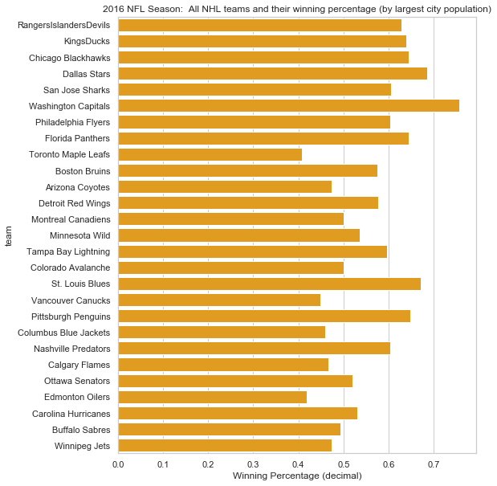

```python
#### Let's take a look at this graphed by WIN_PCT

sns.set(style="whitegrid")
plt.figure(figsize=(8,10))
ax = sns.barplot(x=nhl2['WIN_PCT'], y=nhl2['team'], color='orange')
ax.set_title('2016 NFL Season:  All NHL teams and their winning percentage (by largest city population)')
ax.set_xlabel('Winning Percentage (decimal)');

# Look closely:  This is all the teams organized in order of Metro Population ! ! ! ! ! !
#                You can thus get an idea IF visually you see that larger cities have higher percentages ! ! !
```

```python
def nhl_correlation():
    population_by_region = nhl2.Population
    win_loss_by_region = nhl2.WIN_PCT
    return stats.pearsonr(population_by_region, win_loss_by_region)

nhl_correlation()
```

```
(0.4550397661778433, 0.01708474277138484)
```

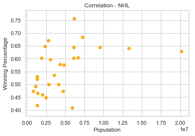

```python
#---  EXAMINING THE MLB DATA SCATTER PLOT  ---

x = nhl2.Population
y = nhl2.WIN_PCT
plt.scatter(x, y, c='orange', alpha=.9)
plt.title("Correlation - NHL")
plt.xlabel("Population")
plt.ylabel("Winning Percentage")
#  plt.scatter(x, y, s=area, c=colors, alpha=0.5)
plt.show();
```

**Thoughts:** * As the population increases, there appears to be an increase in winning percentage * .456 tells the story there is a linear relationship... * This also is the highest correlation we have seen yet. In other words, of all four sports, it looks like HOCKEY HAS THE HIGHEST CORRELATION BETWEEN POPULATION OF THE CITY AND ITS WINNING PERCENTAGE...